# 编程语言：应用与解释 Programming Languages: Application and Interpretation

# 渐进类型 Gradual Typing

## 从脚本到程序 From Scripts to Programs

动态语言程序越长越大，就会越来越难以维护。程序员用类型来定义接口、传达对行为的预期、编写文档，等等；没有类型时，我们就需要各种临时拼凑的工具。换句话说，我们希望“脚本”长大成为“程序”。 As dynamic language programs grow, they become increasingly hard to maintain. Programmers use types to define interfaces, communicate expectations of behavior, document, and so on, and in their absence, we need several ad hoc tools. Put differently, we want “scripts” to grow up and become “programs”.

因此，过去十年中编程语言最显著的趋势之一，就是为动态语言增添一个静态版本。原则上，这不过是给现有语言添加一个类型系统。然而，正如我们在讨论后加的类型时已经看到的 [ 👉 ]，这样的类型系统需要顾及该语言惯用的编程风格；否则，它就会把太多实际上类型正确的程序报告为错误，而这种居高不下的误报率会使人们干脆不用类型系统。因此，我们讨论了一些需要支持的代码模式。 Thus, one of the most visible trends in programming languages over the past ten years is dynamic languages adding a static counterpart. In principle, this is as simple as adding a type-system to an existing language. As we’ve already seen when discussing retrofitted types [ 👉 ], however, such a type system needs to take into account the idiomatic style of programming in the language; otherwise it would report as erroneous too many programs that are actually type-correct, and this high false-positive rate would make people not use the type system at all. Therefore, we discussed some patterns of code that need to be supported.

另一个妨碍采用类型的主要障碍是，人们往往已经积累了大量代码，一口气把所有代码转换成有类型的语言根本不切实际。事实上，其中一些代码甚至可能无法在大多数合理的类型系统中获得类型：例如 eval 构造，它接受一个动态字符串（例如在程序执行期间即时构造的字符串）并运行它。根据定义，我们在静态时并不知道这个字符串是什么；不知道它是什么，就根本不可能静态地为它确定类型。 Another major obstacle to adoption is that people often have a large amount of code lying around, and it is simply impractical to convert all of it to a typed language in one go. In fact, some of it may not even be typeable by most reasonable type systems: e.g., the eval construct, which takes a dynamic string (e.g., one that may be constructed on-the-fly during program execution) and runs it. By definition, we statically do not know what this string is; without knowing it, we can’t possibly type it statically.

简言之，我们不能指望整个程序从无类型瞬间转变为有类型，原因有二： In short, there are two reasons why we cannot expect the whole program to make an instant transition from untyped to typed:

- 程序太大，而程序员还有其他事情要花时间做。 The program is too large, and programmers have other things to do with their time.
- 程序的某些部分甚至可能无法确定类型。 Some parts of the program may not even be typeable.

（不需要 eval，也能让类型难以确定。许多考察并修改程序行为的动态构造也有同样的特点。它们之所以进入语言，是因为语言是动态的，无须顾虑静态类型规约；而后，它们就成了日后引入类型的障碍。） (You don’t need eval to make things hard to type. Many dynamic constructs that look at program behavior and modify it have the same flavor. They enter the language because it’s dynamic and doesn’t have to worry about a static type discipline, and then create an obstacle for later typing.)

尽管如此，人们已经为许多现实中的动态语言建立了类型系统。这些类型系统具有一种称为渐进类型的性质：顾名思义，你“逐渐”给程序添加类型，希望程序中有类型的部分越来越多。它最初是 Scheme 社区中的一个学术想法（2006 年的两篇论文为 Scheme 引入了渐进类型），如今已经广泛用于业界。 Despite this, type systems have been built for many real-world dynamic languages. These type systems exhibit a property called gradual typing : as the name suggests, you add types “gradually” to the program, hopefully making it more-and-more typed. What started out as an academic idea in the Scheme community (two papers in 2006 introduced gradual typing for Scheme) is now [widely used in industry](https://en.wikipedia.org/wiki/Gradual_typing) .

## 微观与宏观 Micro Versus Macro

在渐进类型中，我们要给程序添加注解，然后对程序进行类型检查。在这个宽泛原则之下，有两派思想。 In gradual typing, we are going to add annotations to programs and then type-check the program. Within this broad principle, there are two schools of thought.

在“微观”渐进类型中，我们可以给语言中任意一部分变量添加注解。前面在 Static Python 的例子中，我们已经见过这一点： In “micro” gradual typing we can add annotations to any subset of the variables of the language. We saw this earlier in the Static Python example:

def insort_right(a, x, lo: int = 0, hi: Optional[int] = None):

这里，我们给 lo 和 hi 加了注解，却没有给 a 和 x 加。从易用性的角度来说，这对程序员非常方便：在你关心的部分使用注解，不关心的部分就不用。不幸的是，这也有代价：如今语言复杂得多，程序的任意部分可以是静态的，其他任意部分可以是动态的，两者可以在同一段代码中自由混杂，甚至混在一个表达式或一行代码里（例如，还是这个例子中的 hi = len(a)）。类型系统需要设法应付那些无法有意义地确定类型的构造（如 eval）。此外，以前我们对于有类型的程序拥有清楚而简单的健全性结论；现在，健全性究竟意味着什么却很不明确。于是，程序员可能费尽心思添加注解，却无法清楚地保证能得到什么回报。（如今已有大量文献试图厘清这一点。） Here, we have annotations on lo and hi , but not on a and x . Ergonomically, this is very convenient for the programmer: use annotations for the parts you care about, and not for the parts you don’t. Unfortunately, this comes at a cost: there is now a much more complex language where any parts of a program can be static and any other parts dynamic, and they can freely commingle in the same body of code, even in a single expression or line (e.g., from the same example: hi = len(a) ). The type system needs to somehow deal with constructs it cannot meaningfully type (like eval ). Also, previously we had a clean and simple soundness result for the typed program; now it is rather unclear what soundness means. In turn, that means that programmers may put a lot of effort into annotations, but without a clear guarantee of what they are getting in return. (A large body of literature now tries to make sense of this.)

相比之下，还有另一种方法，通常称为“宏观”渐进类型。在宏观方法中，有两种语言：有类型的语言和动态语言。我们希望它们非常相似——相似到拥有相同的运行时系统，并能自由共享值——所以把它们称为“兄弟”语言。不过，它们未必拥有相同的构造（例如，有类型的语言不会包含 eval）。我们不再把有类型和无类型的代码自由混在一起，而只需要弄清值在两种语言之间传递时会发生什么，不必考虑它们在各自语言内部的情况。预期的做法是，程序员逐渐把代码库的一部分从动态语言迁移到有类型的语言，通常一次迁移一个函数。每种语言都可以从另一种语言导入代码，不过在导入到有类型的代码时，程序员必须为导入的代码指定类型。 In contrast, there is another approach, often called “macro” gradual typing. In the macro approach, there are two languages : the typed and the dynamic one. They are expected to be very similar—so similar that they have the same run-time system and can freely share values—so we’ll refer to them as “sibling” languages. However, they may not have the same constructs (e.g., the typed language would not contain eval ). Instead of freely mixing code between typed and untyped, we only have to figure out what happens when values travel between the languages, not within each one. The expectation is that the programmer will gradually migrate part of their codebase from the dynamic to the typed language, typically a function at a time. Each language can import code from the other, but when importing into typed code, the programmer must specify a type for the imported code.

这种方法的一个典型例子是 Typed Racket。Typed Racket 是历史最悠久、发展最成熟的渐进类型语言之一（严格说来，具有渐进类型的是 Racket 和 Typed Racket 的组合——Typed Racket 本身是完全有类型的），而且对于值在语言之间传递时会发生什么，它还提供了一些最有趣的视角，因此我们将用它作为研究的范例。 A canonical example of this approach is Typed Racket. Because Typed Racket is one of the oldest and most developed gradually typed languages (technically, it’s the combination of Racket and Typed Racket that is gradually typed—Typed Racket itself is fully typed), and also offers some of the most interesting perspective on what happens when values travel between languages, we will use that as our exemplar for study.

## Typed Racket 实战 Typed Racket at Work

在接下来的内容中，密切留意错误消息的具体细节至关重要！ In what follows, it’s critical to pay attention to the exact details of error messages!

首先，让我们在 #lang racket 中编写以下函数，并试着测试它： First, let’s write the following function in #lang racket and test it out:

(define (g s)

(+ 1 (or (string->number s) 0)))

正如我们所料， As we would expect,

> (g "5")

6

因为这个字符串表示一个有效的数， because the string represents a valid number,

> (g "hi")

1

因为这个字符串并不表示一个有效的数，而 because the string doesn’t represent a valid number, and

> (g 5)

string->number: contract violation

expected: string?

given: 5

因为 5 根本不是字符串。 because 5 isn’t a string at all.

现在让我们在 Typed Racket 中定义它： Now let’s define it in Typed Racket:

#lang typed/racket

(define (f [s : String]) : Number

(+ 1 (or (string->number s) 0)))

类型检查器确认，这个程序类型良好。 The type-checker confirms that this program is well-typed.

练习：作为测试，试试 Exercise: As a test, try

(define (f [s : String]) : Number

(+ 1 (string->number s)))

看看会发生什么。 and see what happens.

现在，假设我们从 Typed Racket 导出这个函数： Now suppose we export this function from Typed Racket:

(provide f)

并把它导入 Racket 模块： and import it into the Racket module:

(require "typed.rkt") ;; or whatever filename you’ve chosen

让我们试试同样的三个测试。不出所料，其中两个的表现与之前相同： Let’s try the same three tests. Predictably, two of them work the same:

> (f "5")

6

> (f "hi")

1

第三个仍然产生错误，不过错误的种类大不相同： The third still produces an error, but a rather different kind of error:

> (f 5)

f: contract violation

expected: string?

given: 5

in: the 1st argument of

(-> string? any)

contract from: typed.rkt

blaming: untyped.rkt

(assuming the contract is correct)

at: typed.rkt:5:9

事情是这样的。当我们从 Typed Racket 导出 f 时，并不是直接导出函数的原始形式。相反，Typed Racket 用契约包装函数，在动态环境中“保护”它。因此，导出的函数就好像是 Here’s what is happening. When we export f from Typed Racket, we don’t just export the function in its raw form. Rather, Typed Racket wraps the function in contracts that “protect” it in a dynamic setting. Thus, it is as if the function that was exported was

(define (wrapped-f s)

(if (string? s)

(let ([b (+ 1 (or (string->number s) 0))])

(if (number? b)

b

(error 'contract "returned value was not a Number")))

(error 'contract "provided value was not a String")))

（只是错误消息做了相应调整）。注意，wrapped-f 的行为与我们导入的 f 完全相同：传入 5 时的错误来自契约检查，而不是内部运算。还要注意，这个包装版本很容易以完全机械的方式生成，也就是通过脱糖： (with suitably different error messages). Notice that wrapped-f behaves exactly like our imported f does: the error when given 5 is from a contract check, rather than from an internal operation. Observe also that this wrapped version is quite easy to produce in a completely mechanical way, i.e., through desugaring:

(define (f [ s : String ]) : Number

(+ 1 (or (string->number s) 0)) )

变成了 became

(define (wrapped-f s )

(if ( string? s )

(let ([b (+ 1 (or (string->number s) 0)) ])

(if ( number? b)

b

(error 'contract "returned value was not a Number ")))

(error 'contract "provided value was not a String ")))

练习：为什么我们要把 b 绑定到函数体的结果？为什么不直接使用函数体表达式？ Exercise: Why do we bind b to the result of the body? Why not use the body expression directly?

这种包装的目的，是让类型注解在动态环境中发挥作用。实质上，程序员费力添加了注解，并让程序通过了类型检查器，作为回报，他们便能确信自己的函数不会被滥用：这些检查发生得更早，提供的信息也比内部错误更充分（而且内部错误甚至可能因输入不同而不发生，使错误一直潜伏着！）。 The point of this wrapping is to put the type annotations to work in a dynamic setting. Essentially, the programmer who has put the effort to add annotations and get the program through the type-checker gets assurance that their function will not be abused through checks that are early and more informative than an internal error (that may not even occur, depending on the inputs, leaving the error to lurk!).

这里有个更有趣的例子。我们定义以下有类型的函数： Here is a more interesting example. We define the following typed function:

(define (h [i : (-> String Number)]) : Number

(+ (i "5") 1))

这是它对应的 Racket 版本： Here is its Racket counterpart:

(define (j i)

(+ (i "5") 1))

现在假设我们试图在 Racket 中使用这两个函数。首先定义一个从字符串生成字符串的函数，也就是说，它既不符合 h 也不符合 j 所预期的函数： Now let’s assume we are trying to use both of these from Racket. We first define a function that produces strings from strings, i.e., one that does not match the function expected by either h or j :

(define (str-dbl s) (string-append s s))

现在看看运行 (j str-dbl) 和 (h str-dbl) 时会发生什么。两者都会产生运行时错误，但错误截然不同。前者（完全在 Racket 中）在 + 处报错：“加倍”的字符串被生成，并一路传到 +，由 + 报告违规。相比之下，在后者中，加倍的字符串虽已生成，但当它试图从 (i "5") 返回时，类型 (-> String Number) 已经变成了契约，契约会中止执行，并指出违反了契约！ Now watch what happens when we run (j str-dbl) and (h str-dbl) . Both produce a run-time error, but very different ones. The former (which is entirely in Racket) gives an error at + : the “doubled” string is produced and makes it as far as + , which reports a violation. In contrast, in the latter case, the doubled string is produced but, when it tries to return from (i "5") , the type (-> String Number) has been turned into a contract, which halts execution saying that there is a contract violation!

旁注：要了解 Racket 的契约系统，请参阅 Racket 指南中的 Contracts。 Aside: To get a sense of Racket’s contract system, see [Contracts](https://docs.racket-lang.org/guide/contracts.html) in the Racket Guide.

练习：另一个有趣的静态—动态语言组合是 Racket 和 plait。plait 并不特别努力地迁就 Racket 的惯用写法，尽管在一定程度上也会迁就：回想一下代数数据类型中的谓词和访问器 [ 👉 ]，不过代价是牺牲了静态类型安全。然而，总体而言，plait 试图实现的是 Standard ML 的类型语言。尽管如此，由于 plait 存在于 Racket 的环境中，它的值可以导出，并在 Racket 中使用。在 plait 中试试上面的例子！ Exercise: Another interesting static-dynamic language combination is Racket with plait. plait does not try very much to accommodate Racket idioms, though it does to some extent: recall the predicates and accessors in algebraic datatypes [ 👉 ], though at the cost of static type safety. Largely, however, plait is trying to implement the Standard ML type language. Nevertheless, because plait lives in the context of Racket, its values can be exported and used from Racket. Try the above examples in plait!

# ••••• 非标准模型 ••••• ••••• Non-Standard Models •••••

我们已经见过一些非标准特性，不过它们都得到了广泛使用。这里，我们来看看一些使用不那么广泛的特性（尽管有些正日益受重视，还有些正在复兴），它们却为编程语言的潜能提供了引人入胜的视角。 We have already seen some non-standard features, but they are in widespread use. Here we look at some that are less widely used (though some are growing in prominence, and others are enjoying a renaissance) but provide fascinating views of what programming languages can do.

# 关系 Relations

## 语言谱系 A Language Genealogy

假设我们想记录编程语言的谱系，并确定哪些语言从哪些语言中获取了思想。我们先记录哪些语言直接借鉴了哪些语言：例如，Java 直接借鉴了 C++，而 C++ 直接借鉴了 C。由此，我们还可以沿着借鉴链追踪后代。 Suppose we want to record a genealogy of programming languages and determine which languages obtained ideas from which ones. We start by recording which languages directly borrowed ideas from which ones: e.g., Java directly borrowed from C++, and C++ directly borrowed from C. From that, we can also trace the descendants down a chain of borrowing.

我们将用下面这种也许有些奇怪的语法，写出其中一些关系： We will write some of these in the following, maybe peculiar, syntax:

borrows(A, B)

表示语言 A 借鉴了语言 B（即 A 较新，B 较旧）。出于另一个奇怪的原因，我们不用引号来写常量，而是把它们写成以小写字母开头、由字母和数字构成的字符串。在此约定下，下面是一些事实（其中 cpp 代表 C++）： means that the language A borrows from the language B (i.e., A is newer, B is older). For another peculiar reason, we will write constants not as quotes but as alphanumeric strings with a lower-case initial . Given that, here are some facts (with cpp standing for C++):

borrows(java, cpp).

borrows(cpp, c).

borrows(c, bcpl).

borrows(pascal, algol).

现在我们可以表达后代的概念：A 可以通过两种方式成为 B 的后代。一种是 A 直接借鉴了 B。另一种是它借鉴了某个语言 Z，而 Z 本身是 B 的后代。我们用下面的语法表达这两条规则： Now we can express the notion of being a descendant: there are two ways that A can be a descendant of B . One is if A borrows directly from B . The other is if it borrows from some language Z that is itself a descendant of B . We express these two rules using this syntax:

descends(A, B) :- borrows(A, B).

descends(A, B) :- borrows(A, Z), descends(Z, B).

恭喜，你刚刚写出了自己的第一个 Prolog 程序。要看看它如何运行，可以使用在线 SWI Prolog。但是，“运行”它是什么意思呢？Prolog 会回答问题：我们可以提出这样一些问题： Congratulations, you’ve just written your first Prolog program. To see this run, you can use [SWI Prolog online](https://swish.swi-prolog.org/) . But what does it mean to “run” this? Prolog answers questions: we can ask several questions like:

cpp 借鉴了 c 吗？ Does cpp borrow from c ?

borrows(cpp, c).

→ true

cpp 借鉴了 bcpl 吗？ Does cpp borrow from bcpl ?

borrows(cpp, bcpl).

→ false

也就是说，可以看出 Prolog 在扮演一个基本数据库的角色。但我们还能做更多： That is, we can see that Prolog is acting like a basic database. But we can do more:

cpp 是 bcpl 的后代吗？ Does cpp descend from bcpl ?

descends(cpp, bcpl).

→ true

bcpl 是 cpp 的后代吗？ Does bcpl descend from cpp ?

descends(bcpl, cpp).

→ false

啊哈：所以 Prolog 不仅会查询基本事实，还会通过规则处理查询。 Aha: so Prolog will not only query basic facts, it will also process queries through rules.

但实际上，我们还能向 Prolog 提出更复杂的问题，看起来更像是函数应用。请看： But we can actually ask Prolog more sophisticated questions that look more like function applications. Consider:

cpp 借鉴了什么？ What does cpp borrow from?

borrows(cpp, X).

→

X = c

这似乎把 borrows 当成了一个相当奇怪的函数：用一个变量（以大写字母开头的名称）来调用它，让 Prolog 填入这个变量。这只适用于基本定义，还是也适用于规则？ This seems to treat borrows like a rather funny function, calling it with a variable (a name that begins with a capital letter) and letting Prolog fill in the variable. Does that work only for basic definitions, or also for rules?

cpp 是什么的后代？ What does cpp descend from?

descends(cpp, X).

→

X = c

X = bcpl

哦，这很有趣！Prolog 并非只返回一个答案；它返回了所有答案。而这一切是通过使用变量（以大写字母开头的名称）完成的。这自然让我们想问：如果反过来做呢？ Oh, this is interesting! Prolog didn’t return just one answer; it returned all the answers. And this was done by using a variable (a name that begins with a capital letter ). This naturally suggests the question, what if we did it the other way around?

什么是 cpp 的后代？ What descends from cpp ?

descends(X, cpp).

→

X = java

这就更奇怪了：仿佛把一个变量作为实参传入，并询问哪些输入能让函数产生某个特定结果！ This is even stranger: it’s like passing a variable as an argument and asking what inputs will produce a particular result from the function!

实际上，用函数来理解这一切根本就不对。在 Prolog 中，我们定义的是关系。因此，borrows 和 descends 实际上都是关系，其中一个（borrows）由具体例子定义，另一个（descends）由抽象规则定义。 In fact, a function is just the wrong way to think about any of this. What is happening in Prolog is that we’re defining relations . So borrows and descends are actually relations, where one (borrows) is defined by concrete examples and the other (descends) by abstract rules.

一旦理解了它们是关系，我们就不必再把自己局限于只有一个借鉴来源，这样也更符合现实。也就是说，假设我们的事实集合如下： Once we understand these are relations, we no longer need to limit ourselves to just one source of borrowing, to better reflect reality. That is, let’s say this is our set of facts:

borrows(java, cpp).

borrows(cpp, c).

borrows(cpp, simula).

borrows(smalltalk, simula).

borrows(self, smalltalk).

borrows(c, bcpl).

borrows(pascal, algol).

borrows(scheme, algol).

borrows(scheme, lisp).

borrows(javascript, self).

borrows(javascript, scheme).

现在我们可以问，究竟有哪些语言对 JavaScript 作出了贡献： Now we can ask what all languages contributed to JavaScript:

descends(javascript, X).

从这组事实中，我们得知： From this set of facts, we learn:

X = self

X = scheme

X = smalltalk

X = simula

X = algol

X = lisp

同样，我们可以问 Lisp 的影响传播得有多广： Similarly, we can ask how widely Lisp’s influence spread:

descends(X, lisp).

我们得知，对于这个非常有限的语言集合： And we learn that for this very limited set of languages:

X = scheme

X = javascript

## 对类型规则进行编码 Encoding Type Rules

你可能已经注意到，我们正在编写的规则，与之前写过的类型规则非常相似。让我们看看能否直接对它们进行编码。 You may have noticed that we’re writing rules that are quite similar to the typing rules we’ve written. Let’s see whether we can encode them directly.

首先，我们需要对语法常量的规则进行编码： First, we need to encode the rules for syntactic constants:

tc(numE, numT).

tc(strE, strT).

tc(boolE, boolT).

我们将用 Prolog 常量 numE 表示语法中的数值表达式，其他以此类推。 We will use the Prolog constant numE to stand for a syntactic numeric expression, and so on.

现在，仅凭已经掌握的知识，我们就能对条件表达式的规则进行编码： Now, using just what we already know, we can encode the conditional rules:

tc(plusE(L, R), numT) :-

tc(L, numT),

tc(R, numT).

tc(catE(L, R), strT) :-

tc(L, strT),

tc(R, strT).

tc(ifE(C, T, E), Ty) :-

tc(C, boolT),

tc(T, Ty),

tc(E, Ty).

注意，这确确实实只是对之前所写规则进行了一次语法转换！ Note that this is literally just a syntactic transformation of the rules we wrote before!

有了这些，我们现在可以把 Prolog 用作检查器： With this, we can now use Prolog as a checker :

tc(ifE(boolE, plusE(numE, numE), numE), numT).

→ true

也可以把它用作计算器： and as a calculator :

tc(ifE(boolE, plusE(numE, numE), numE), Y).

→

Y = numT

但我们还能做更有意思的事：如果在程序中留下变量呢？ But we can do something much more intriguing: what if we leave variables in the program ?

tc(ifE(boolE, plusE(numE, Y), numE), numT).

这是在要求 Prolog 想出一些程序，使这个程序具有数值类型。Prolog 的回应是： This is asking Prolog to come up with programs that will make this program have numeric type. Prolog responds with:

Y = numE

Y = plusE ( numE , numE )

Y = plusE ( numE , plusE ( numE , numE ))

Y = plusE ( numE , plusE ( numE , plusE ( numE , numE )))

（以及更多结果；这些项的结构透露出 Prolog 工作方式的一些信息）。也就是说，Prolog 正在扮演程序合成器的角色。 (and many more; the structure of terms reveals something about how Prolog works). That is, Prolog is acting as a program synthesizer .

现在来看看如何扩展它以包含类型环境。为此，我们必须扩充类型规则，也把环境包括进来。回想一下，环境对公理没有影响，而其他规则只是把环境传递下去： Now let’s see how to extend this to include the type environment. For that, we have to enlarge our typing rules to include an environment as well. Recall that the environment doesn’t matter for the axioms, while the other rules just pass the environment through:

tc(numE, _, numT).

tc(strE, _, strT).

tc(boolE, _, boolT).

tc(plusE(L, R), Env, numT) :-

tc(L, Env, numT),

tc(R, Env, numT).

tc(catE(L, R), Env, strT) :-

tc(L, Env, strT),

tc(R, Env, strT).

tc(ifE(C, T, E), Env, Ty) :-

tc(C, Env, boolT),

tc(T, Env, Ty),

tc(E, Env, Ty).

现在添加三条与变量相关的规则。我们将用一个由 bind 关系构成的列表来表示环境。查找变量时，我们通过模式匹配检查该变量是否位于第一个绑定中；如果是，就可以返回相应的类型，否则必须在剩余绑定中继续搜索： Now let’s add the three variable-oriented rules. We will use a list of bind relations to capture the environment. To look up a variable, we pattern-match on whether the variable is the first binding; if it is we can respond with the relevant type, otherwise we must search in the remaining bindings:

tc(varE(V), [bind(V, T) | _], T).

tc(varE(V), [bind(_, _) | RestTEnv], T) :-

tc(varE(V), RestTEnv, T).

Prolog 记法 [ … | … ] 表示把列表分解为 | 左侧的首元素（即头）和 | 右侧的其余部分（即尾）。 The Prolog notation [ … | … ] means to decompose a list into a first, or head, element to the left of the | and the rest, or tail, to the right of the | .

另外两条规则看起来更像我们之前写的类型规则： The other two rules look much more like the type rules we wrote earlier:

tc(lamE(V, B), TEnv, funT(A, R)) :-

tc(B, [bind(V, A) | TEnv], R).

注意，在上面的规则中，我们已经去掉了类型注解！这条规则看起来更像是在做类型推断，而不是类型检查。最后： Observe that in the above rule, we have done away with the type annotation! This rule looks more like what we would write with type inference than with type checking . Finally:

tc(appE(F, A), TEnv, U) :-

tc(F, TEnv, funT(T, U)),

tc(A, TEnv, T).

现在，我们可以把这些定义用于之前做类型推断时用过的例子。让我们转换先前的这个程序（我们只有单参数函数）： We can now use these definitions with the example we used for type inference . Let’s translate this program (we have only single-argument functions) from before:

(lambda (v)

(lambda (w)

(if v

(+ w 1)

(+ w 2))))

我们把它按以下方式编码后传给 tc 关系，把类型环境和结果类型保留为变量： We pass this to the tc relation, encoded as follows, with the type environment and result type left variable:

tc(lamE(v,

lamE(w,

ifE(varE(v),

plusE(varE(w), numE),

plusE(varE(w), numE)))), TEnv, T)

Prolog 产生以下输出： Prolog produces the following output:

T = funT ( boolT , funT ( numT , numT ))

换句话说，它实际上推断出了函数的类型：v 具有布尔类型，w 具有数值类型，而整个表达式的结果是一个数。 In other words, it has effectively inferred the type of the function: v has Boolean type, w has numeric type, and the result of the whole expression is a number.

也就是说，它推断出了参数的类型。现在我们来看一些有类型错误的程序： In other words, it has inferred the types of the parameters. Now let’s consider some type-erroneous programs:

tc(lamE(v, ifE(boolE, strE, numE)), _, _)

→ false

这里，Prolog 告诉我们，它找不到任何变量名能满足这种形状的程序。但如果我们改为给它一个留有表达式空缺、需要填补的程序： Here, Prolog tells us it can’t find any variable name that would satisfy this shape of program. But if instead we give it a program with holes to fill in for expressions:

tc(lamE(w, ifE(A, strE, numE)), _, _)

Prolog 会尝试构造越来越大、可能可行的项，并为了寻找一个能确定类型的程序而陷入无限循环！一般来说，这是合成系统面临的一个问题：如果给定的问题有解，它们通常能很快找到一个解；但如果无解，它们就必须花很长时间尝试寻找——如果搜索空间很大但有限，就会非常久；如果空间无限，就会无限久。合成器往往会用启发式方法截断这种搜索。 Prolog tries to build bigger and bigger terms that might work, and goes into an infinite loop trying to find a program that is typeable! In general, this is a problem for synthesis systems: if the problem they are given has a solution they can often find one quickly, but if it does not have a solution, they have to spend a long time trying to find one—either very long, if it’s a large but finite space to search, or infinitely long, if the space is infinite. Often, synthesizers will use heuristics to truncate this search.

## 可视化 Prolog 执行 Visualizing Prolog Execution

下面是一段经典视频（摄于 1988 年），展示了一个可视化 Prolog 执行的工具： Here’s a classic video (from 1988) of a tool that visualizes Prolog execution:

https://www.youtube.com/watch?v=pLcfMEQjMqM

# 生成器 Generators

## 一个典型例子 A Canonical Example

考虑下面这个使用生成器的典型 Python 程序： Consider the following canonical Python program that uses generators:

def nats():

n = 0

while True:

yield n

n += 1

g = nats()

next(g) + next(g) + next(g)

得到 0 + 1 + 2 = 3。但它是如何工作的？ produces 0 + 1 + 2 = 3 . But how does it work?

从文字层面，我们可以这样理解。nats 看起来像一个函数，但其中有关键字 yield。这使它不再是函数，而是生成器。它的主体先把 n 初始化为 0，然后进入无限循环。每轮循环，它先产出 n 的当前值，然后递增 n，再继续循环。 At a textual level, we can understand it as follows. nats looks like a function, but it has the keyword yield in it. This makes it not a function but a generator . Its body initializes n to 0 , then goes into an infinite loop. Each time through the loop, it yields the current value of n , then increments it, before continuing the loop.

在 nats 的定义之外，我们将 g 定义为生成器的一个实例，每次调用 next 都会得到下一个产出的值。这解释了结果。我们需要做的是理解 nats 内部正在发生什么，从而理解生成器的一般工作方式。 Outside the definition of nats , we define g to be an instance of the generator, and each call to next gets the next yielded value. This explains the result. What we need to do is understand what is going on inside nats , and hence what happens with generators in general.

显然，我们不能把 nats（或它返回的生成器）看成函数。若这样看，它显然会进入无限循环。这意味着第一次 next 调用就会永远运行下去；它永远不会产生值，也就无法进行下一次 next 调用以及第三次调用来求和。要明白这一点，想象我们改用下面这个版本： It is clear that we cannot think of nats (or of the generator returned by it) as a function. If we do, then clearly it goes into an infinite loop. That means the very first next call would run forever; it would never produce a value, which enables the next next call, and then the third, producing the sum. To see this, imagine we had the following version instead:

def natsr():

n = 0

while True:

return n

n += 1

natsr() + natsr() + natsr()

这里，虽然 natsr（“带有 return 的 nats”）包含无限循环，但每当 Python 执行 return 时，就会终止函数并返回。此外，下次调用时，我们又从 natsr 的开头重新开始。因此，每次调用都产生 0，总和也就是 0。 Here, even though natsr (“ nats with return ”) has an infinite loop, every time Python runs the return , it halts the function and returns. Furthermore, on the next call, we start again from the beginning of natsr . As a result, each call produces 0 so the sum is also 0 .

相比之下，nats（创建的生成器）显然不是这样运行的。相反，很明显，正如 yield 这个名称所暗示的那样，计算会在 yield 发生时暂停。当我们调用 next 时，计算并不是从 nats 的最开头开始；如果是那样，n 就会是 0。它会从上次停下的地方继续，因此 n 的值会递增，并开始 while 循环的下一轮迭代。 In contrast, that is clearly not what is happening in (the generator created by) nats . Rather, it’s clear that—as the name yield suggests—the computation is halting when the yield occurs. When we call next , computation does not start at the top of nats ; if it did, n would be 0 . Instead, it resumes from where it left off, so that the value of n is incremented and the next iteration of the while loop occurs.

如果这一切听起来很像闭包保留着某个作用域里的变量，那么你的思路是对的。不过，要更深入地理解，我们需要更仔细地观察求值过程。虽然可以在 Python Tutor 中运行它，但那个工具其实并没有提供理解这个程序所需的支持。因此，我们将转向 Stacker。 If all of this sounds suspiciously like variables in a scope being held on to by a closure, you’re on the right track. To understand this more, though, we need to peer a bit more closely at the evaluation. While we could run this in the [Python Tutor](https://pythontutor.com/python-debugger.html#mode=edit) , that tool does not really have the support necessary for us to understand what is happening in this program. Instead, we will turn to our Stacker.

旁注：在 Python 中，生成器只是更一般的迭代器概念之上的语法糖。迭代器响应 next 协议。若想了解生成器如何脱糖为迭代器，请参阅这篇 StackOverflow 帖子。若想更深入地理解 Python 生成器，请参阅这篇论文的第 4.1 节和第 4.3 节。 Aside: In Python, generators are merely syntactic sugar over the more general notion of iterators . Iterators respond to the next protocol. To learn how a generator desugars into an iterator, see [this StackOverflow post](https://stackoverflow.com/questions/2776829/difference-between-pythons-generators-and-iterators) . To understand Python generators in more depth, see sections 4.1 and 4.3 of [this paper](https://cs.brown.edu/~sk/Publications/Papers/Published/pmmwplck-python-full-monty/) .

## 转换为 SMoL Translating to SMoL

假如 SMoL 有 yield 的概念（其实没有），下面的程序就大致模拟了上面的 Python 程序。为了避免未绑定标识符错误，我们将使用下面这个简单的 yield 定义： The following program is a rough simulation of the above Python program if SMoL had a notion of yield , which it does not. To avoid unbound identifier errors, we will use the following simple definition of yield :

(deffun (yielder n)

n)

然后，我们可以把上面的代码转换如下： We can then translate the above code as follows :

(deffun (gen)

(defvar n 0)

(deffun (loop)

(yielder n)

(set! n (+ n 1))

(loop))

(loop))

(+ (gen) (gen) (gen))

为简单起见，我们忽略生成器实例化这一步：也就是说，在这个版本里，生成器只能有一份，而 Python 版本允许我们实例化多个。稍后我们会再讨论这一点。 For simplicity, we’re ignoring the step where we instantiate the generator: i.e., we can have only one copy of the generator in this version, whereas the Python version lets us instantiate multiple. We will return to this later.

注意，运行上面的程序会陷入无限循环，因为 yield 并不会“让出”。不过，由于 Stacker 会展示计算的中间步骤，它仍然能提供非常有用的信息。 Observe that running the above program goes into an infinite loop, because yield does not “yield”. However, because the Stacker shows us intermediate steps in the computation, it still provides something very useful.

既然有了这个程序，我们就把它放进 Stacker 运行。我们会看到几个初始状态，然后看到一个像这样的状态： Now that we have this program, let’s run it through the Stacker. We will see a few preliminary states, and then one that looks like this :

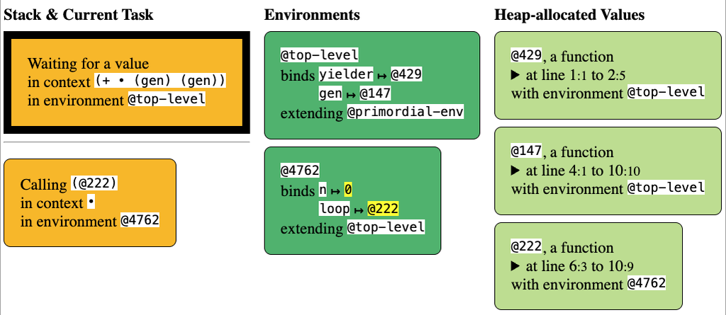

此时，最早的帧表示顶层表达式，它正在等待对 gen 的第一次调用完成计算。在 gen 内部，我们已经把 n 初始化为 0。现在即将开始计算这个（可能）无限的循环。 At this point, the oldest frame represents the top-level expression, which is waiting for the first call to gen to compute. Inside gen , we have initialized n to 0 . Now we are about to start computing the (potentially) infinite loop.

稍后，我们会看到如下状态： A little bit later, we see the following :

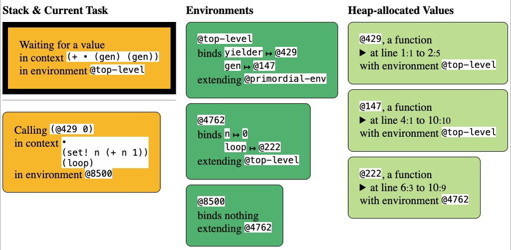

这幅图就是生成器的精髓。理解它至关重要。 This picture is the essence of generators. Understanding it is critical.

这里发生的事情如下。顶层计算正在等待 gen 调用结束并产生答案。在生成器内部，计算已经初始化 n，正准备产出它的当前值。关键在于这个操作的上下文： Here is what is happening here. The top-level computation is waiting for the call to gen to finish and produce an answer. Within the generator, the computation has initialized n and is about to yield its current value. What is critical is the context of this operation:

•

(set! n (+ n 1))

(loop)

位于 @8500 中，它没有绑定，因此转而使用 @4762。后者将 n 绑定为 0。 in @8500, which has no bindings and hence defers to @4762. This binds n to 0 .

现在，假设我们能把这个栈拆成两部分（根据需要共享环境和存储区）： Now, suppose we could break up this stack into two parts (with the environment and store shared as needed):

(+ • (gen) (gen))

位于 @top-level 中 in @top-level

•

(set! n (+ n 1))

(loop)

位于 @8500 中 in @8500

注意，每一部分单独看起来都像一个完整的栈！环境 @top-level 指向顶层所使用的名称（如 gen），而环境 @8500（从而也包括 @4762）指向生成器所使用的名称（如 n）。 Observe that each part looks like a full-fledged stack in its own right! The environment @top-level refers to names that the top-level uses (such as gen ), while the environment @8500 (and hence @4762) refers to ones that the generator uses (such as n ).

不过，直到现在，我们都一直假定程序只有一个栈。生成器最简单的概念模型是： Until now, however, we have acted as if a program has only one stack. The simplest conceptual model for a generator is:

每个生成器实例都有自己的局部栈。 Each generator instance has its own local stack.

也就是说，生成器的栈不知道主程序或其他生成器中的计算。它只知道自己正在进行的计算。一次 yield 会做两件事： That is, the generator’s stack does not know about the computation in the main program or in any other generators. It only knows about the computation that it is performing. A yield does two things:

1. 它透明地（也就是在程序员不知情的情况下）把局部栈保存在生成器的数据结构中。 It transparently (i.e., without the programmer’s knowledge) stores the local stack with the generator data structure.
2. 它把产出的值返回给调用生成器的那个栈。 It returns the yielded value to the stack that invoked the generator.

其他一切——变量、别名、闭包、栈随函数调用和返回而增长与缩减，等等——都保持不变。唯一的区别在于，调用生成器会在一个独立、不相连的栈中开始计算，或恢复先前的上下文。 Everything else—variables, aliasing, closures, growth and decline of the stack with functions calls and returns, etc.—stays exactly the same. The only difference is that calling a generator causes computation to start, or resume the context, in a separate, disconnected stack.

因此，在上述模型中，第一次 yield 成功之后，顶层栈帧会是 Thus, in the above model, after the first yield succeeds, the top-level stack frame would be

(+ 0 • (gen))

并调用生成器。这会恢复之前的栈，于是 n 被设为 1，循环运行下一轮迭代，这一轮会 invoking the generator. This would resume the previous stack, so n would be set to 1, and the next iteration of the loop would run, which would

1. 保存生成器的栈（从概念上说，它与之前完全相同——只有 n 的值发生了变化，但那是在环境中），并且 Store the generator’s stack (which, conceptually, is exactly the same—only the value of n has changed, but that is in the environment), and
2. 把 n 的新值（即 1）返回到顶层栈。 return the new value of n (i.e., 1 ) to the top-level stack.

这样就得到 This would result in

(+ 0 1 •)

重复上述过程，从而产生 3。 repeating the above process, and hence producing 3 .

## 一个更丰富的例子 A Richer Example

利用已经学到的知识，我们来考虑另一个 Python 例子： Using what we have learned, let us consider another Python example:

def nats():

n = 0

while True:

yield n

n += 1

def odds():

ns = nats()

while True:

n = next(ns)

if n % 2:

yield n

g = odds()

next(g) + next(g) + next(g)

这个程序有两个不同的生成器创建器：一个是我们已经见过的自然数生成器创建器，另一个对自然数进行筛选，只产生奇数。 This program has two distinct generator creators: the one we’ve already seen for natural numbers, and one more that filters the natural numbers to produce only odd numbers.

现在，我们可以把控制流程理解如下。首先，创建 odds 的一个实例，并将它绑定到 g。这会立即创建 nats 的一个实例，并在 odds 实例内部把它绑定到 ns。现在，所有生成器都已准备就绪，可以开始计算。 We can now think of control proceeding as follows. First, we make an instance of odds and bind it to g . This immediately creates an instance of nats and binds it (within the instance of odds ) to ns . Now all our generators are set up and ready to compute.

现在开始 odds 中的无限循环。这会调用自然数生成器。此时，奇数生成器的局部栈如下 We now begin the infinite loop in odds . This calls the natural number generator. At this point, the odd number generator’s local stack looks like

while True:

n = •

if n % 2:

yield n

所在环境中，ns 绑定到一个生成器，而 n 尚未初始化 in an environment where ns is bound to a generator and n is uninitialized

由于我们调用的是生成器而不是函数，计算现在会在该生成器自己的栈中运行。这是我们已经研究过的自然数生成器。它把 n 绑定为 0，然后执行 yield，保存自己的局部栈—— Because we have called a generator, not a function, computation now runs in that generator’s own stack. This is the natural number generator, which we have already studied. It binds n to 0 and then yield s, storing its local stack—

while True:

•

n += 1

所在环境中，n 绑定为 0 in an environment where n is bound to 0

——并把 0 返回给奇数生成器。 —and returning 0 to the odd number generator.

这会恢复奇数生成器的栈。它把 n 绑定为 0，然后进行比较。比较失败，继续执行循环体： This resumes the odd generator’s stack. This binds n to 0 and performs the comparison. It fails, continuing the loop body:

n = next(ns)

if n % 2:

yield n

现在我们又准备调用自然数生成器了。奇数生成器的局部栈与之前相同（上下文相同，环境也相同，只是这次环境中确实有了 n 的绑定，值为 0）。与此同时，自然数生成器从以下位置恢复 Now we are again ready to invoke the natural number generator. The odd number generator’s local stack is unchanged from before (same context, same environment, except this time the environment does have a binding for n , to 0 ). Meanwhile, the natural’s generator resumes from

while True:

•

n += 1

所在环境中，n 绑定为 0 in an environment where n is bound to 0

它会递增 n，并继续执行循环体： This increments n and resumes the loop body:

yield n

n += 1

这立即使它产出 1，留下的栈为 This immediately causes it to yield 1 , leaving the stack

while True:

•

n += 1

所在环境中，n 绑定为 1 in an environment where n is bound to 1

这会恢复奇数生成器的栈。它把 n 绑定为 1，因此条件成立。所以，产出时的栈变成 This resumes the odd generator’s stack. This binds n to 1 , so the conditional succeeds. Therefore, the stack at the point of yielding becomes

while True:

n = next(ns)

if n % 2:

•

所在环境中，ns 绑定到一个生成器，而 n 绑定为 1 in an environment where ns is bound to a generator and n is bound to 1

这样就完成了第一次 next(g) 调用，使顶层栈帧拥有如下上下文 This completes the first call to next(g) , enabling the top-level stack frame to have the context

1 + • + next(g)

由此可以看出，接下来两次计算将产生 3 和 5，因此总和为 9。 From this, we can see the next two computations will produce 3 and 5 , and hence the total of 9 .

# 惰性 Laziness

## 求值策略 Evaluation Strategies

早在我们开始研究求值时 [ 👉 ]，就看到执行求值时存在一个选择。在函数应用期间，可以把实参作为表达式来替换，也可以作为值来替换。当时我们指出，SMoL 是急切的。现在我们来研究另一个选择：惰性。 Back when we began to study evaluation [ 👉 ], we saw that we had a choice when performing evaluation. During function application, we could substitute the actual parameter as an expression or as a value . At that time, we indicated that SMoL is eager. Now we will investigate the other option, laziness.

考虑下面的程序： Consider the following program :

(deffun (f x)

(g (+ x x)))

(deffun (g y)

(h (* y 2)))

(deffun (h x)

(+ x 5))

(f (+ 2 3))

在 Stacker 中以急切方式运行时，会看到这样的调用 When run eagerly in the Stacker, we see calls like

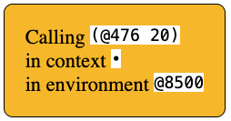

其中，环境的内容如下 where the environment contents look like

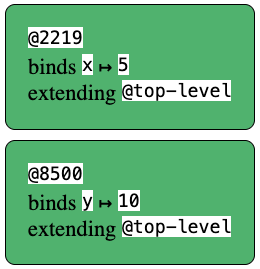

调用和环境都再次表明：在函数体开始执行之前，参数就已经被求值，因此名称绑定的是值。 Both the call and the environment reinforce that parameters are evaluated before the function body begins to execute, so names are bound to values .

## 为什么采用惰性求值 Why Lazy Evaluation

现在假设我们改为惰性地对它求值。求值过程如下： Suppose, instead, we evaluate this lazily. The evaluation would look like this:

(f (+ 2 3))

→ (g (+ (+ 2 3) (+ 2 3)))

→ (h (* (+ (+ 2 3) (+ 2 3))) 2))

→ (+ (* (+ (+ 2 3) (+ 2 3))) 2) 5)

一个很自然的问题是：为什么要费这个劲？ A natural question might be, why bother doing this?

1. 人们经常提到的一个理由是，这能节省时间，因为不必对不需要的参数求值。例如，假设有 (deffun (f x y z) (if (zero? x) y z))，我们调用 f，最后两个位置的参数计算起来都很昂贵。在急切语言中，不管愿不愿意，我们都会对两者求值。在惰性语言中，只会对所需的那一个求值。如下文将看到的，这其实并不是一个很有说服力的论点。 A reason people often cite is that it can save time, in that we don’t need to evaluate parameters we don’t need. For instance, suppose we have  
   (deffun (f x y z)  
   (if (zero? x)  
   y  
   z))  
   and we call f with two expensive-to-compute parameters in the last two positions. In an eager language, we have evaluated both whether we want to or not. In a lazy language, we only evaluate the one we need. As we will see below, this is actually not a very compelling argument.
2. 第二个理由是，它让我们能通过函数给语言添加新的非急切构造。考虑 if：在急切语言中，它不能是函数，因为 if 的全部意义就在于不对某个分支求值（如果变成函数，分支就会成为需要求值的参数）。同样，这个论点的价值也有些有限：我们已经见过如何用宏添加这样的构造，而且宏还能做多得多的事情。 A second reason is that it enables us to add new, non-eager constructs to the language through functions. Consider if : in an eager language it can’t be a function because the whole point of if is to not evaluate one of the branches (which would become parameters that are evaluated). Again, this argument has somewhat limited merit: we have seen how we can add such constructs using macros, which can do a great deal more as well.
3. 最有趣的理由大概是，支配语言的等式集合会发生变化。请考虑以下情况。假设我们有表达式 E 和 (lambda (x) (E x))。它们“相同”吗？直觉上似乎是的。假设 E 是一个函数。在任何把 E 应用于某个参数的场合，第二个表达式所做的事都完全相同：它接受该参数，把它绑定到 x，然后把 E 应用于 x，效果相同。然而，要注意，E 未必是函数！它可能是一条打印语句、(/ 1 0)，等等。在这些情况下，E 会立刻求值，并产生某种可观察的效果；而“藏在 lambda 下面”的版本，在被使用之前不会如此。这为什么重要？因为编程实现和工具的许多部分都希望用某些项替换另一些项。优化编译器会这样做（按照所使用的优化标准，把某项替换为一个更好的等价项），程序重构引擎等工具也会这样做。因此，能够替换的项越多，或替换所需的条件越少，就越好。惰性语言允许替换更多的项。 The most interesting reason is probably that the set of equations that govern the language changes . Consider the following. Suppose we have the expressions E and (lambda (x) (E x)) . Are they the “same”? It would seem, intuitively, that they are. Suppose E is a function. In any setting where we apply E to a parameter, the second expression does exactly the same: it takes that parameter, binds it to x , and then applies E to x , which has the same effect.  
   However, note that E may not be a function! It could be a print statement, (/ 1 0) , and so on. In those cases, E evaluates right away and has some observable effect, but the version “hidden under the lambda ” will not until it is used.  
   Why does this matter? It matters because many parts of programming implementations and tools want to replace some terms with other terms. An optimizing compiler does this (replacing a term with an equivalent one that is better by whatever optimizing criterion is in use), as do program refactoring engines, and more. Thus, the more terms that can be replaced, or the fewer conditions under which terms can be replaced, the better. Lazy languages allow more terms to be replaced.

术语：这种等价关系称为“eta 规则”（η）。 Terminology: This equivalence is called “rule eta” (η).

术语：你可能会看到有人说惰性语言具有“引用透明性”。如果请他们定义这个词，他们也许会说“可以用相等的东西替换相等的东西”之类的话。想一想：你总是可以用相等的东西替换相等的东西。按照某些定义，这恰恰就是相等的含义：两个东西相等，当且仅当你可以用一个替换另一个。因此，这句话什么也没告诉我们。事实上，每种语言都有某种程度的“引用透明性”：总有一些东西可以用其他等价的东西替换。在惰性语言中，通常可替换的东西更多：引用透明关系更大。仅此而已。 Terminology: You may see some people say that lazy languages have “referential transparency”. If you ask them to define it, they may say something like “you can replace equals with equals”. Think about that for a moment: you can always replace equals with equals. That is (by some definitions) literally what equality means : two things are equal exactly when you can replace one with the other. So that phrase tells us nothing. In fact, every language has some degree of “referential transparency”: you can always replace some things with other equivalent things. In lazy languages, the set of things you can replace is usually bigger: the referential transparency relation is larger. That’s all.

4. 一个非常重要而实用的理由，是创建可能无限的数据结构。请看下面关于流的例子。 One very important, practical reason is to create potentially-infinite data structures. See the example on streams below.
5. 更根本地说，著名论文《为什么函数式编程很重要》（Why Functional Programming Matters）主张惰性是一种模块化概念，并通过几个优美的例子展开了这一论证。 More fundamentally, the famous paper [Why Functional Programming Matters](https://www.cse.chalmers.se/~rjmh/Papers/whyfp.html) argues that laziness is a modularity concept, and develops this argument through several beautiful examples.

## 严格点 Strictness Points

回到之前的例子：在采用惰性求值的语言中运行这样的程序时，所有这些算术运算究竟会在什么时候算出结果并打印出一个值？或者说，它们会这样做吗？ Coming back to our example from earlier: when we run such a program in a language with lazy evaluation, when, if ever, does all this arithmetic resolve and print a value?

回答这个问题之前，我们还要注意，程序有时确实无法无限推迟作出决定。例如，考虑这个程序： Before we answer that question, let us also observe that sometimes programs can’t really defer decisions indefinitely. For instance, consider this program:

(deffun (f x)

(if (even? x)

7

11))

(f (+ 2 3))

尝试对它求值会发生什么？想必替换会把它归约为 What happens when we try to evaluate it? Presumably substitution reduces this to

(if (even? (+ 2 3))

7

11)

然后呢？想必可以把这视为“答案”，但似乎并不怎么有用；而在实际程序中，这些项只会变得越来越大。此外，假设程序是 and now what? Presumably that could be considered “the answer”, but that doesn’t seem very useful; and in real programs, these terms would just grow larger and larger. Furthermore, suppose the program were

(deffun (fact n)

(if (zero? n)

1

(* n (fact (- n 1)))))

(fact 5)

我们当然可以产生如下答案 We can certainly produce as an answer

(if (zero? 5)

1

(* 5 (fact (- 5 1)))))

但是……接下来呢？而且，这个回答中的 fact 又是什么？这看起来不像一种很有用的编程语言。 but…then what? And for that matter, what is fact in this response? This does not seem like a very useful programming language.

因此，惰性编程语言会把语言中的某些位置定义为严格点，在这些位置，表达式被强制进行计算并产生答案。选择不同的严格点，会得到行为略有差异的语言。通常，以下位置被认为是有用的严格点： Instead, lazy programming languages define certain points in the language as strictness points, which are points where expressions are forced to compute and produce an answer. Different choices of strictness points will result in languages that behave slightly differently. Conventionally, the following are considered useful strictness points:

1. 条件表达式中的条件部分。这使语言能够确定选择哪个分支、忽略哪个分支。 The conditional portion of a conditional expression. This enables the language to determine which branch to take and which branch to ignore.
2. 算术运算。这能避免积累起很长的计算链。 Arithmetic. This avoids long chains of computations building up.
3. 交互式环境中的打印器。这让该环境变得有用。 The printer in an interactive environment. This makes the environment useful.

这三者都是出于实用考虑的选择。注意，上面的第一个例子涉及顶层打印器，而第二个例子涉及条件表达式。 All three of these are pragmatic choices. Notice that our first example above concerned the top-level printer, while the second example has to do with conditionals.

由于存在这些严格点，典型的惰性语言实际上会以与急切语言非常相似的方式计算上面那些程序。要看到真正区分急切与惰性的情况，我们需要更丰富的程序。 Because of these strictness points, a typical lazy language will in fact compute the programs we have seen above very similarly to an eager language. To get to something that really differentiates eagerness from laziness, we need to get to richer programs.

## 不用替换进行求值 Evaluating Without Substitution

上面，我们看到了如何用替换来理解惰性求值。虽然这是一种有用的心智模型，但正如从之前的解释器中看到的，我们其实不想把替换用作实现策略。那需要反复改写程序源代码，而我们的解释器并不是这样工作的。 Above, we saw how we can think of lazy evaluation using substitution. While this is a useful mental model, as we have seen in earlier interpreters, we don’t really want to use substitution as our implementation strategy. That involves repeatedly rewriting program source, which is not how our interpreter worked.

所以，假设我们传递的不是值，而是“表达式”。这是否意味着，上述序列变成下面这样？ So let’s say we don’t pass the value but instead “the expression”. Does it mean the above sequence becomes this?

(f (+ 2 3))

→ (g (+ x x))，其中 x 绑定到 (+ 2 3) → (g (+ x x)) where x is bound to (+ 2 3)

→ (h (* y 2))，其中 y 绑定到 (+ (+ 2 3) (+ 2 3))) → (h (* y 2)) where y is bound to (+ (+ 2 3) (+ 2 3)))

→ (+ x 5)，其中 x 绑定到 (* (+ (+ 2 3) (+ 2 3)) 2) → (+ x 5) where x is bound to (* (+ (+ 2 3) (+ 2 3)) 2)

实际上，就连这样也不完全正确。应该是 In fact, even this isn’t quite right. It should rather be

(f (+ 2 3))

→ (g (+ x x))，其中 x 绑定到 (+ 2 3) → (g (+ x x)) where x is bound to (+ 2 3)

→ (h (* y 2))，其中 y 绑定到 (+ x x))，后者中的 x 是 (+ 2 3) → (h (* y 2)) where y is bound to (+ x x)) whose x is (+ 2 3)

→ (+ x 5)，其中 x 绑定到 (* y 2)，后者中的 y 是 (+ x x))，其中的 x 又是 (+ 2 3) → (+ x 5) where x is bound to (* y 2) whose y is (+ x x)) whose x is (+ 2 3)

换句话说，我们想要传递未经求值的表达式……但你大概看得出这会走向哪里！稍不留神，就会得到动态作用域。即使先不考虑这一点，我们也不能只传递表达式本身，因为等到最终遇上严格点时，我们根本不会知道变量解析出来的值是什么。 In other words, we want to pass the unevaluated expression…but you can probably see where this is going! If we’re not careful, we will end up with dynamic scope. Even setting that aside, we can’t just pass the expression on its own, because when we eventually get a strictness point, we simply will have no idea what value a variable resolves to.

不过，解决方案也非常自然地浮现出来。我们不只传递表达式，还要一并传递它对应的环境。表达式与环境结合，就形成了……闭包！当然，这个闭包不接受任何参数；它唯一的任务是暂停表达式的求值，直到遇到严格点，然后在正确的环境中对它求值。幸运的是，我们不需要在这里做任何新工作；闭包应用已经替我们完成了这些。 However, the solution also presents itself very naturally. We don’t just pass an expression, we pass along its corresponding environment. An expression and environment combine to form a…closure! Of course, this closure does not take any parameters; its only job is to suspend the evaluation of the expression until we reach a strictness point, and at that point, evaluate it in the right environment . Fortunately, we don’t need to do any new work here; closure application already does it for us.

## 通过闭包实现惰性：超越数值 Laziness Via Closures: Beyond Numbers

当我们考虑数据结构时，惰性就更有趣了。按照惯例，数据构造器不是严格的，因此不会急切地对它们的实参求值。我们可以用列表来说明，不过严格来说，我们构造的是流（流是无限的，而列表是有限的）。 Laziness becomes more interesting when we consider data structures. Conventionally, data constructors are not strict, so their arguments are not evaluated eagerly. We can illustrate this using lists, though technically we will be constructing streams (which are infinite, as opposed to lists, which are finite).

首先，阅读关于用闭包表示流的内容： First, read about streams represented using closures:

https://dcic-world.org/2025-02-09/func-as-data.html#%28part._streams-from-funs%29

在本来就是惰性的语言中，同样的代码会是什么样子？ What would the same code look like in a language that was already lazy?

为了做这个实验，我们现在将使用 Racket 语言 To experiment with that, we’ll now use the Racket language

#lang lazy

(define ones (cons 1 ones))

(define (nats-from n)

(cons n (nats-from (add1 n))))

(define nats (nats-from 0))

(define (take n s)

(if (zero? n)

empty

(cons (first s) (take (sub1 n) (rest s)))))

观察其中一些值打印出来是什么样子： Observe how some of these values print:

> ones

#<promise:ones>

> nats

#<promise:nats>

“promise”这个词意味着，它们是表示流的 thunk。要查看 thunk 的内容，需要“强制兑现”这个“承诺”，为此我们使用 ! 运算符： The word “promise” means these are thunks that represent the stream. To view the thunk’s content, we need to “force” the “promise”, which we do using the ! operator:

> (! ones)

#0='(1 . #<promise!#0#>)

> (! nats)

'(0 . #<promise:...e/pkgs/lazy/base.rkt:299:29>)

对于 ones，Racket 告诉我们，流的其余部分与当前正在查看的是同一个流：也就是说，它是一个循环流。对于 nats，它告诉我们，第一个元素是 0，后面跟着另一个 promise。我们可以再进一步探索这些流： In the case of ones , Racket is telling us that the rest of the stream is the same stream as the one we are viewing: i.e., it’s a cyclic stream. For nats , it tells us that the first element is 0 , followed by another promise. We can explore these streams a bit further:

> (! (rest ones))

#0='(1 . #<promise!#0#>)

> (! (rest (rest (rest ones))))

#0='(1 . #<promise!#0#>)

> (! (rest nats))

'(#<promise:...e/pkgs/lazy/base.rkt:299:29> . #<promise:...e/pkgs/lazy/base.rkt:299:29>)

> (! (rest (rest (rest nats))))

'(#<promise:...e/pkgs/lazy/base.rkt:299:29> . #<promise:...e/pkgs/lazy/base.rkt:299:29>)

不出所料，ones 没有变化。不过，对于 nats，随着我们探索流的更多部分，会遇到更多 thunk。这时 take 就派上用场了：它给出可能无限的流的一段有限前缀。不幸的是，这似乎也只是产生更多 thunk，看起来我们得费劲地对每个部分应用 !： Unsurprisingly, ones does not change. But with nats , as we explore more of the stream, we run into more thunks. This is where take is useful: it gives us a finite prefix of the potentially infinite stream. Unfortunately, that also seems to just produce more thunks, and it seems like we would need to laboriously apply ! to each part:

> (take 10 ones)

'(#<promise:...e/pkgs/lazy/base.rkt:299:29> . #<promise:...e/pkgs/lazy/base.rkt:299:29>)

> (take 10 nats)

'(#<promise:...e/pkgs/lazy/base.rkt:299:29> . #<promise:...e/pkgs/lazy/base.rkt:299:29>)

像这种我们知道输出将是有限的情况，可能希望把所有 thunk 都求值出来。为此，Lazy Racket 提供了 !!，它会递归地对所有包含的 thunk 强制求值： For situations like this, where we know the output is going to be finite, we might want to resolve all the thunks. For this, Lazy Racket provides !! , which recursively applies strictness to all contained thunks:

> (!! (take 10 ones))

'(1 1 1 1 1 1 1 1 1 1)

> (!! (take 10 nats))

'(0 1 2 3 4 5 6 7 8 9)

果然，我们得到了预期的答案。 Sure enough, we get the expected answer.

练习：如果对 ones 和 nats 应用 !!，会发生什么？试一试，并解释你看到的现象。 Exercise: What happens if we apply !! to ones and to nats ? Try it out, and explain what you see.

## 跟踪惰性 Tracing Laziness

理解惰性的另一种方法，是在 Stacker 中研究流的编码。代码如下： Another way to understand laziness is to study the encoding of streams in the Stacker. Here is the code:

#lang stacker/smol/hof

(deffun (lz-first s) (left s))

(deffun (lz-rest s) ((right s)))

(deffun (take n s)

(if (equal? n 0)

empty

(cons (lz-first s) (take (- n 1) (lz-rest s)))))

(defvar ones (mpair 1 (λ () ones)))

(deffun (nats-from n)

(mpair n (λ () (nats-from (+ n 1)))))

(defvar nats (nats-from 0))

现在分别运行 Now run each of

(take 3 ones)

(take 3 nats)

并研究何时发生求值，以及闭包保留着什么。（你可能会发现，一次只看其中一个会更有帮助：先看 ones 的定义和使用，再单独看 nats 和 nats-from。） and study when evaluation happens and what is being held on to by the closures . (You may find it helpful to view just one of these at a time: the definition and use of ones , and separately of nats and nats-from .)

## 惰性与副作用 Laziness and Side-Effects

既然惰性求值具有这些（潜在的）好处，为什么它没有得到更广泛的使用？ Given the (potential) benefits of lazy evaluation, why is laziness not more widely used?

问题在于，对于使用状态的程序，惰性会让预测程序行为困难得多。因此，流行的惰性语言没有状态，或者只以严格受控的形式提供状态。（这并不是坏事！状态本就应当只以严格受控的方式使用，例如 Haskell 就有非常有趣的设计来帮助实现这一点。不过，程序员历来习惯于不受限制地使用状态。） The problem is that laziness makes it much harder to predict what will happen in programs that use state. Therefore, popular lazy languages do not have state, or have it in very controlled forms. (This is not a bad thing! State should only be used in very controlled ways, and Haskell, for instance, has very interesting designs that help with that. But programmers have traditionally expected to have unfettered access to state.)

例如，考虑下面这一对函数： Consider, for instance, the following pair of functions:

(define (f x y)

(g x y))

(define (g x y)

(if (zero? (random 2)) x y))

单独看，它们似乎无害。不过，现在考虑这个调用： On their own, they seem harmless. However, now consider this call:

(f (print "X") (print "Y"))

在急切语言中，我们知道两个字符串都会立刻打印。然而，在惰性语言中，只会打印其中一个，而且我们无法判断是哪一个。为了弄清楚，我们不能再把 f 当作抽象，而必须查看它的实现，这又迫使我们也去检查 g 的源代码。为了确定哪些效果会发生、又在何时发生，我们必须检查每一次调用，并跟踪沿途所有严格点。再看一个例子： In an eager language, we know both strings would be printed right away. However, in a lazy language, only one will, and we cannot tell which one. To understand which, we can no longer treat f as an abstraction but instead have to peer into its implementation, which in turn forces us to examine the source of g as well. We would have to examine every call, and track all the strictness points along the way, to determine which effects will occur and when. Here is another example:

(define n 0)

(f (set! n (add1 n)) (set! n (sub1 n)))

同样，如果急切地运行，我们知道在 f 的函数体开始求值之前，n 就会被重新设为 0。而在惰性求值中，我们无法确定 n 的值：它可能是 -1，也可能是 1。此外，如果明天把 g 改成 Again, if we ran this eagerly, we know n would be set back to 0 before the body of f even begins to evaluate. In lazy evaluation, we cannot be sure what value n will have: it could be -1 or 1 . Furthermore if, tomorrow, g were altered to be

(define (g x y)

(if (zero? (random 2)) "X" "Y"))

那么 n 会保持为 0——但不检查代码，我们就无从得知！ then n remains 0 —but we can’t know without examining its code!

读到这些程序，一个自然的反应可能是：“别这样写！”这其实是完全合理的反应。问题不在惰性本身，而在于惰性与状态之间的相互作用。随着我们不再提倡在编程中不受限制地使用状态，惰性的潜力会随之增长。不过，还有些情况——例如错误——无法避免，而它们可能在惰性求值下潜伏不露。 A natural reaction to reading these programs might be, “Don’t do that!” That is in fact an entirely legitimate reaction. The problem is not laziness: it’s the interaction between laziness and state. As we deprecate the use of unfettered state in programming, that increases the potential for laziness. Still, there are other situations—like errors—that we cannot avoid, and that can stay latent under lazy evaluation.

## 缓存结果 Caching Results

如果采用没有副作用的惰性编程，我们会得到一个不错的好处：每个表达式总是产生相同的结果。在这种情况下，就根本不必重新计算表达式；只需存储它的结果，在后续访问时复用即可。也就是说，可以缓存结果，从而用空间换时间。 If we use lazy programming without side effects, we get a nice benefit: each expression always produces the same result. In that case, we don’t ever have to recompute an expression; we can just store its result and reuse it on subsequent accesses. That is, we can cache the result, enabling us to trade space for time.

旁注：如果你不熟悉计算中以空间换时间的做法——例如记忆化和动态规划等技术所采用的方式——请参阅 DCIC：https://dcic-world.org/2025-02-09/avoid-recomp.html Aside: If you are not familiar with trading space for time in computation—as found in techniques such as memoization and dynamic programming—see DCIC:  
https://dcic-world.org/2025-02-09/avoid-recomp.html

不过，可以进行的结果缓存有两种。 There are, however, two kinds of result caching one can perform.

一种是 Lazy Racket 所做的：把每个表达式的结果局部缓存起来。这意味着，如果同一个源代码位置被多次求值，就可以复用缓存值。其他实现策略甚至能在动态环境中寻找相同的表达式（例如 Fibonacci 函数会动态产生子问题）。这需要截然不同的实现方法，却可能带来更大的时空权衡收益。 One is what happens in Lazy Racket, where each expression’s result is cached locally. This means that if the same source location is evaluated multiple times, the cached value can be reused. Other implementation strategies can look for the same expression even in a dynamic setting (as happens, for instance, in a Fibonacci function, which dynamically generates sub-problems). This requires a rather different implementation approach, but can yield even bigger time-space trade-offs.

## 空间消耗 Space Consumption

能够自动对计算进行记忆化，似乎让默认采用惰性求值更有好处了。为什么不这样做呢？ The ability to automatically memoize computation seems to show even more benefit to making lazy evaluation a default. Why not do it?

(define (sq x)

(* x x))

由于采用惰性求值，x 绑定到一个以闭包表示的表达式。现在假设我们的程序如下 Because we are evaluating lazily, x is bound to an expression represented as a closure. Now suppose our program looks like

(define v (make-vector 1000 0))

(sq (vector-ref v 2))

## 急切之中的惰性 Laziness in Eagerness

由于这些问题，惰性作为默认选项并未流行起来。同时，它在某些场景中又非常有用。正如上面看到的，我们总可以用 thunk 来模拟惰性。不过，这在语法上可能很笨拙，所以有些语言为此提供了语法支持。例如，在 Racket 这样的语言中，delay 是一种语法形式，会把它的表达式包装成 thunk，而 force 是一个对它求值（并缓存结果）的函数。 As a result of these issues, laziness has not gained popularity as a default option. At the same time, it is very useful in some settings. As we have seen above, we can always simulate laziness by using thunks. This can, however, be syntactically unwieldy, so some languages provide syntactic support for it. In languages like Racket, for instance, delay is a syntactic form that thunks its expression, and force is a function that evaluates it (caching the result).

# Web 上的控制 Control on the Web

## 服务器端编程 Server-Side Programming

考虑这样一个程序： Consider a program like this:

print(read("First number") + read("Second number"))

想象在传统的命令行操作系统上运行这个程序。调用 read 时会发生什么？它会调用操作系统的同步输入读取命令：“同步”意味着程序暂停执行——也就是说，栈保持完整——等待用户回应（如果用户真的回应的话）；当用户回应时，程序的栈会恢复，用户输入的值就成为 read 返回的值。 Imagine we were to run this program on a traditional command-line operating system. What happens when we call read ? The operating system’s synchronous input-reading commands are invoked: synchronous meaning that the program suspends its execution—that is, the stack stays intact—waiting for the user to respond (if ever they do), and when they do, the program’s stack resumes, with the value typed in by the user becoming the value returned by read .

这看起来如此简单直接，以至于我们可能从未仔细想过，这种能力有多么了不起。要理解这一点，我们应该试着在 Web 上运行这个程序。这样一来，就会迎面撞上 Web 的一个核心问题：那里没有“read”操作这样的东西。为什么没有呢？ This seems so straightforward that we might never think twice about how remarkable this ability is. To understand that, we should try to run this program on the Web. When we do, we run headlong into a central problem on the Web: that there is no such thing as a “ read ” operation. Why not?

在 Web 上，一个假想的 read 函数当然可以把提示发送给客户端。原则上，它接下来应该等待客户端回应一个值，然后返回该值。然而，Web 的无状态特性意味着这不可能发生：程序必须终止。这是一个异步操作。当用户回应时（如果用户真的回应的话），已经没有等待着供其返回的计算了。 On the Web, a hypothetical read function can certainly send the prompt to the client. In principle, it should then wait for the client to respond with a value, which it returns. However, the stateless nature of the Web means that this can’t happen: the program has to terminate. This is an asynchronous operation. When the user responds (if they ever do), there is no computation waiting to go back to.

### 记录上下文 Recording Contexts

因此，Web 计算必须采用截然不同的安排。程序员必须手动记住剩余的计算，并把它保存在某个地方。例如，我们可以按以下方式拆分上面的程序：接下来要做什么： Therefore, a Web computation has to be arranged in a very different way. The programmer must manually remember the rest of the computation, and store it somewhere. For instance, we would break up the above program in the following way: what is going to be done next:

read("First number")

以及什么正在等待结果： and what is waiting for the result:

print(• + read("Second number"))

（这当然就是我们的老朋友：上下文。）不过，上下文本来隐含在程序的栈上，而由于程序必须终止，现在就需要把上下文显式写出来。当然，• 不是程序操作；相反，我们可以把上下文看成一个单参数函数： (This is, of course, our old friend, a context.) But whereas the context is implicit on the program’s stack, because the program must terminate, the context needs to be written out explicitly. Of course, • is not a program operation; rather, we can think of the context as a function of one argument:

lam(• 1 ): print(• 1 + read("Second number"))

而保存的正是这个函数，其保存方式与发出的提示相关联。然后，当（如果）用户回应时，其回应值就绑定到 • 1，使程序得以恢复。例如，假设用户输入 5，那么这个程序实际上变成 and this is the function that is stored in a way associated with the outgoing prompt. Then, when (if) the user responds, their response value is bound to • 1 , allowing the program to resume. Suppose, for instance, the user types 5 . Then this program effectively becomes

print(5 + read("Second number"))

它也需要进行一次 Web 交互，所以我们再次把它拆成现在必须发生的事情 This needs to also perform a Web interaction, so we again split it into what must happen now

read("Second number")

以及等待结果的部分： and what is waiting for the result:

print(5 + •)

我们可以把后者表示为函数： which we can represent as a function:

lam(• 2 ): print(5 + • 2 )

如果用户恢复交互，那么在恢复时，这个函数就会应用于用户提供的值，结果也会如预期那样打印出来。 If and when the user resumes, this function is applied to the value they supply, and the result prints as we would expect.

这个解释略过了一些重要细节。正如我们见过的，真正的程序求值不是通过改写程序来进行的，因此第二个函数实际上并不是 This explanation glosses over some important details. Real program evaluation, as we have seen, does not proceed by rewriting programs, so the second function is not really

lam(• 2 ): print(5 + • 2 )

而是一个闭包，其函数体为 but rather a closure with the body

lam(• 2 ): print(• 1 + • 2 )

并封闭于一个将 • 1 绑定为 5 的环境中。从 Web 架构的角度看，深入这些细节很有趣；不过，对我们而言，唯一关心的是：上下文必须被保存和恢复。 closed over an environment where • 1 is bound to 5 . Getting into these details is interesting from a Web architecture perspective, but for us, all we care about is that contexts must be saved and restored .

### 在 Stacker 中模拟 Simulating in the Stacker

只要放弃输入操作，假装它总是返回某个常量，就可以用 Stacker 模拟上述过程： We can [simulate the above using the Stacker](https://smol-tutor.xyz/stacker/?syntax=Lispy&randomSeed=defvar&hole=%E2%80%A2&nNext=0&program=%28deffun+%28get-number+s%29%0A++5%29%0A%0A%28%2B+%28get-number+%22first%22%29+%28get-number+%22second%22%29%29%0A) , provided we forego the input operation and pretend it always returns some constant:

#lang stacker/smol/hof

(deffun (get-number s)

5)

(+ (get-number "first") (get-number "second"))

在第二次调用发生时，我们看到的状态如下： At the point of the second call, we see that the state looks [like this](https://smol-tutor.xyz/stacker/?syntax=Lispy&randomSeed=defvar&hole=%E2%80%A2&nNext=3&program=%28deffun+%28get-number+s%29%0A++5%29%0A%0A%28%2B+%28get-number+%22first%22%29+%28get-number+%22second%22%29%29%0A) :

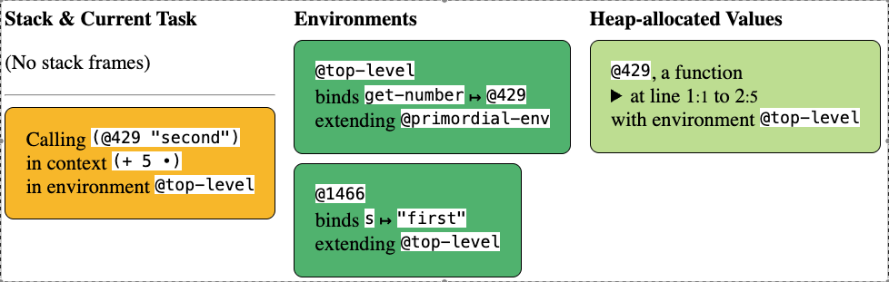

## 客户端终止 Client-Side Termination

在 Web 客户端的 JavaScript 中，我们看到同样的现象，不过原因完全不同。想象我们在 JavaScript 中编写阶乘计算： On the client-side Web, in JavaScript, we see the same phenomenon, but for a completely different reason. Imagine we write a factorial computation in JavaScript:

function fact(n) {

ans = 1;

while (n != 0) {

ans = ans * n;

n = n - 1;

}

return ans;

}

注意，循环检查的是 n != 0，而不是 n > 0，因此如果把它放进网页运行，原则上程序会永远运行下去： Notice that the loop checks for n != 0 and not n > 0 , so if we put this in a Web page and run it, the program will in principle run forever:

<script type="application/javascript">

function fact(n) {

ans = 1;

while (n != 0) {

ans = ans * n;

n = n - 1;

}

return ans;

}

function show() {

window.alert('here');

ans = fact(-1);

window.alert(ans);

document.getElementById('answer').innerHTML = ans;

}

</script>

</head>

<body>

<button onclick="show()">Click me</button>

<div id="answer"></div>

然而，这会带来一个问题：JavaScript 虚拟机一次只运行一个计算，而同一个 JavaScript 虚拟机还管理着页面和浏览器组件。因此，如果页面里的程序陷入无限循环，整个页面就不再响应。正因为如此，过一会儿浏览器就会弹出一个窗口，询问是否终止该计算。 However, this creates a problem: the JavaScript virtual machine runs only one computation at a time, and the same JavaScript virtual machine also manages the page and the browser’s components. Therefore, if the program inside a page goes into an infinite loop, the entire page stops being responsive. For this reason, after a little while, the browser will pop up a window offering to kill the computation.

JavaScript 对此有解决办法，但谈不上优雅。程序员创建一个闭包——称为回调——来表示剩余的计算。然后程序员调用 There is a solution to this in JavaScript, but it is hardly elegant. The programmer creates a closure—called a callback —that represents the rest of the computation. The programmer then calls

setTimeout(C, 0)

或者，在更现代的程序中， or, in more modern programs,

requestAnimationFrame(C)

（不过前一种写法也许更能看清发生了什么），其中 C 是回调。这会创建一个事件，尽快运行 C（在 0 个时间单位之后）。随后，程序员——听起来熟悉吗？——终止程序。这会把控制权交还给 JavaScript 虚拟机。它运行其他待处理事件，接着轮到这个事件，就立即运行它——也就是通过 C“回调”进原来的计算。如果 C 构造得正确，就能正确恢复计算，仿佛从未停过一样。呼！ (though the former version perhaps makes a bit clearer what is happening), where C is the callback. This creates an event to run C as soon as possible (after 0 units of time). The programmer then—does this sound familiar?— terminates the program . This returns control to the JavaScript virtual machine. It runs any other pending events, then arrives at this event, which it runs immediately—i.e., it “calls back” into the computation using C . If C was constructed correctly, then this properly resumes the computation, as if it had never halted. Phew!

## 抽象这个问题 Abstracting the Problem

因此，在 Web 的服务器端和客户端，我们遇到了同样的问题。原因截然不同，但最终效果一致：程序员必须手动跟踪需要持久保留的信息，把它存到某处，停止计算以便把控制权交还给调用方，并在恢复时从存储中取回信息；所有这些代码都必须运行得与从未发生中断时完全一样。 Thus, we have the same problem on both the server and client sides of the Web. The reasons are very different, but the net effect is the same: the programmer has to manually keep track of information that needs to persist, store it somewhere, halt the computation to return control to whatever called it and, when resumed, fetch information back from storage; all this code must run exactly as if an interruption had never occurred.

这种编程困境并不新鲜。早在计算机发展的初期，程序员就必须手动跟踪值位于内存中的什么地方；后来有了编译器，替我们完成这项工作。之后，我们又必须手动跟踪堆上的分配，以便稍后回收；再后来，有了垃圾回收器替我们做这件事。编程语言的历史中，这样的任务比比皆是：起初由程序员手动完成，直到我们学会创建能够自动完成它们的语言构造和编译器。如果这里也能这样做，减轻编写此类程序的负担，那就好了。 This programming quandary is not new. Back in the early days of computing, programmers had to manually keep track of where in memory values resided; then we got compilers that did this for us. Then we had to manually keep track of allocation on the heap to later reclaim it; then we got garbage collectors to do this for us. The history of programming languages is full of tasks that programmers did manually until we learned to create language constructs and compilers that could do these automatically. It would be nice if we could do the same here to reduce the burden of writing such programs.

为了更好地研究这些现象，如果能抽离服务器、客户端、JavaScript、网页、超时等细节，考察这一现象的本质，会很有帮助。 To study these phenomena better, it would be helpful if we could abstract away from the details of servers, clients, JavaScript, Web pages, timeouts, and so on, and examine the phenomenon in its essence.

### 使用闭包 Using Closures

我们可以假定一个新原语 get-number/k，来模拟这个解决方案。它不只接受提示字符串这一个实参，还接受第二个实参。第二个实参是一个表示剩余计算的闭包——也就是说，是用闭包表示的栈。这个函数把该闭包绑定到变量 resume，然后……什么也不做： We can simulate the solution by assuming a new primitive, get-number/k . Instead of taking one argument, the prompt string, it also takes a second argument. This second argument is a closure that represents the rest of the computation—i.e., it’s the stack represented as a closure. This function binds that closure to a variable, resume , and then…does nothing:

(defvar resume #f)

(deffun (get-number/k s rest)

(set! resume rest))

回想一下，我们希望程序调用这个函数，然后停止；所有剩余的计算——即上下文——都需要放在传给 get-number/k 的第二个参数中。因此，我们的程序现在如下： Recall that we want the program to invoke this function and then halt; all remaining computation—the context—needs to be in the second parameter given to get-number/k . Thus, our program now looks like this:

(get-number/k "first"

(λ (•1)

(get-number/k "second"

(λ (•2)

(+ •1 •2)))))

术语：第二个实参体现了全部剩余计算，称为续延，传统上用字母 k 表示它。 Terminology: The second argument—embodying the entire rest of the computation—is called the continuation , and it’s traditional to use the letter k for it.

术语：上面的程序结构被翻了个里朝外：原先第一个操作位于最内层，最后一个操作位于最外层；现在第一个在最外层，最后一个在最内层。这种笨拙的程序结构有个名字：控制反转。原本是调用方调用辅助函数，以获得它的值（本例中是 get-number）；现在却是辅助函数（本例中是 get-number/k）调用调用方。这导致一种不自然、笨拙而容易出错的编程风格。 Terminology: The program structure above has been turned inside-out: instead of the first operation being innermost and last operation outermost, the first one is outermost and the last one is innermost. This unwieldy program structure has a name: inversion of control . Instead of the client calling the helper function whose values it wants (in this case, get-number ), the helper function (in this case get-number/k ) calls the client. This leads to an unnatural, unwieldy, and error-prone programming style.

果然，当我们运行这个程序时，它就这样……停止了，没有输出。看看程序结束时的状态很有启发性： Sure enough, when we run this program , it just…halts with no output. It is instructive to look at the state of the program when it ends :

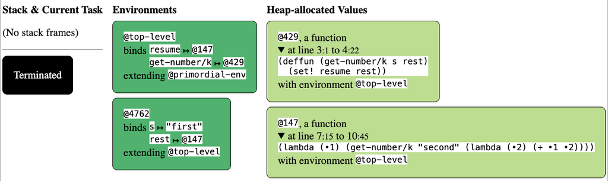

注意，resume 绑定到一个正在等待数值的函数。如果修改程序，调用它： Notice that resume is bound to a function that is awaiting a number. If we modify the program to invoke it:

(resume 5)

那么新的最终状态就变成： then our new final state becomes:

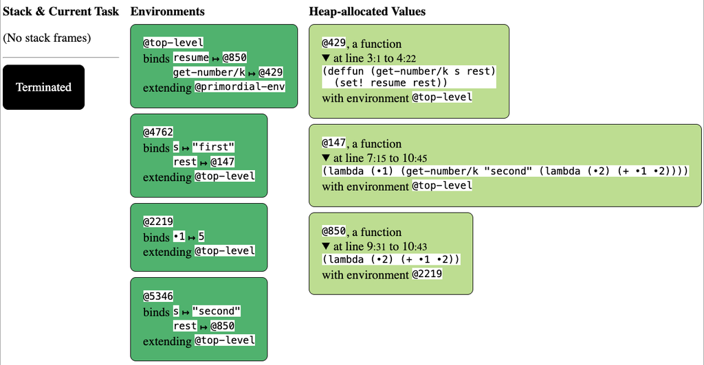

注意，resume 现在绑定到一个闭包，其环境记住了 •1 的值。如果现在修改程序，再次恢复： Observe that resume is now bound to a closure whose environment remembers the value of •1 . If we now modify the program to resume again:

(resume 7)

这个“程序”自然结束，输出 12！（我们给“程序”加引号，是因为我们实际上把原本简单的程序拆成了三个：第一个取得第一次输入所需的提示，第二个记住该值并提示第二次输入，第三个则对这两个值求和。） the “program” halts naturally , with an output of 12 ! (We use quotes around “program” because we have really fragmented our simple program into three: one that gets the prompts for the first input, one that remembers that value and prompts for the second, and the third that sums those two values.)

### 使用 Racket Using Racket

原来，Racket 也有操纵续延的工具。 It turns out that Racket also has tools for manipulating continuations.

想象 DrRacket 中有两个标签页。在第一个标签页中（假设将其保存为 "yielder.rkt"），我们有以下神秘的程序： Imagine we have two tabs in DrRacket. In the first (let’s suppose we save it as "yielder.rkt" ) we have the following mysterious program:

#lang racket

(provide yield resume)

(define resumer #false)

(define (yield)

(let/cc k

(set! resumer k)

(raise 'yield)))

(define (resume)

(resumer 'dummy))

let/cc 操作将指定的变量（这里是 k）绑定到一个续延值：它把当前栈变成一个可以当作函数处理的值。 The operation let/cc binds the named variable (here, k ) to a continuation value: it turns the current stack into a value that can be treated as a function.

在另一个标签页中，我们要编写一个简单程序，假扮那个长时间运行的计算：一个阶乘函数。当然，可以直接在 Racket 中运行它。但根据输入不同，fact 可能会运行很久；因此，遵循 JavaScript 的规则，我们希望它周期性地停止，比如每当 n 能被 5 整除时（也就是大约每五轮迭代一次）。也就是说，我们希望运行： In another tab, we will write a simple program that pretends to be our long-running computation: a factorial function. We can run this directly in Racket, of course. But fact could run for a very long time, depending on the input; so following the rules of JavaScript, we want it to halt periodically, let’s say every time n is divisible by 5 (i.e., roughly every five iterations). That is, we would like to run:

#lang racket

(require "yielder.rkt")

(define (fact n)

(if (= n 0)

1

(if (zero? (modulo n 5))

(begin

(yield)

(* n (fact (- n 1))))

(* n (fact (- n 1))))))

其中，(yield) 使它暂停，而在运行 (resume) 时，计算会恰好从先前停下的位置继续。事实上，我们会看到如下结果： where (yield) makes it pause in a way that, when we run (resume) , the computation will pick up exactly where it left off. Indeed, we see the following outcome:

> (fact 7)

uncaught exception: 'yield

> (resume)

5040

它第一次让出是在 n 为 5 时。这里的让出，指用 Racket 的异常机制终止计算。恢复操作以某种方式使计算继续，并运行到完成；令人惊叹的是，它产生的答案与计算从未停止过时完全一样！ The first time it yields is when n is 5 . Yielding, in this case, means terminating the computation using the Racket exception mechanism. Resuming somehow causes computation to continue and run to completion but, remarkably, it produces the exact same answer as if computation had never halted at all!

注意，由于使用了 let/cc，我们得以把反转的控制再反转回来，也就是以所谓直接风格编写程序。语言负责保存和恢复计算，无须用户程序手动处理。因此，续延是将控制反转再次反转的有用工具。我们还会看到另一种能做到这一点的语言机制：非 SMoL：响应式。 Observe that thanks to the use of let/cc , we have been able to invert the inverted control, i.e., write the program in what is called direct style . The language has taken care of storing and restoring the computation without the user program having to do it manually. Thus, continuations are useful tools for inverting inverted control. We will also see another language mechanism that does this: [Non-SMoL: Reactivity](https://docs.google.com/document/d/1ECyFV88K-jU-i0qHLfUNjbIYthChzpcjZ0eiostD3d8/edit#) .

## 在 Web 服务器上让出 Yielding on a Web Server

Racket Web 服务器有一个特殊原语，正是为 Web 做这件事的。我们将分阶段构建它。首先，使用一种特殊的 Racket 语言，它旨在让服务器端 Web 程序更容易编写： The Racket Web server has a special primitive that does just this for the Web. We’ll build it up in stages. First, we’ll use a special Racket language, designed to make it easier to write server-side Web programs:

#lang web-server/insta

这种语言的程序必须有一个名为 start 的“主”函数，它接受初始请求（即首次运行计算时提供的各种信息）。编写这个函数时，我们作一个方便的假设：存在一个 get-number 函数，它会打印提示、发出一个网页、等待回应、提取输入的值，并将其作为数值返回： Programs in this language must have a “main” function, called start , which is given an initial request (whatever information is provided when we first run the computation). This function is then written assuming a convenient fiction: the existence of a function get-number that will print a prompt, send out a Web page, wait for its response , extract the value entered, and return it as a number:

(define (start req)

(let ([result (+ (get-number "first") (get-number "second")) ])

(response/xexpr

`(html (body (p "The result is " ,(number->string result)))))))

如果能让这个假设成真，我们就能编写上面那样的程序：在一个“深层”上下文中调用 get-number 两次，把结果相加，再将结果转换成字符串，以便嵌入网页。 If we can make this fiction reality, then we can write a program like the above: it calls get-number in a “deep” context, twice, adds the results, and then converts the result into a string to embed it into a Web page.

问题当然是，这样的函数如何可能存在。首先，我们得讨论 Web 的一些机制。创建 Web 表单时，它需要一个叫 action 的字段，里面存放一个 URL。当用户提交表单时，浏览器会把表单各字段中输入的信息打包起来——实际上是一组键值对——发送到该 URL，也就是发给服务器，请求它运行该 URL 对应的程序，并把这些键值对提供给这个程序。 The question, of course, is how such a function can exist. First, we have to discuss some Web mechanics. When we create a Web form, it needs a field called the action , which holds a URL. When the user submits the form, the browser bundles up the information entered into the fields of the form and sends them—effectively, as a set of key-value pairs— to the URL , i.e., to the server, requesting it to run the program at that URL and provide the key-value pairs to that program.

因此，可以看出，我们已经把暂停程序执行的问题，转化成了能否给这个 URL 填入有意义内容的问题。如果 URL 能以某种方式对应到栈，也许就能恢复栈（从而恢复计算），并向它提供这些键值对，程序便能从中提取所需信息。 Therefore, we can see that we’ve turned the problem of suspending the program’s execution into one of being able to fill in this URL with something meaningful. If the URL can somehow correspond to the stack, then perhaps the stack (and hence the computation) can be restored, and can be provided with these key-value pairs, from which the program can extract the required information.

Racket Web 服务器提供的“秘方”，是一个名为 send/suspend 的原语。它会做以下事情： The “secret sauce” that the Racket Web server provides is a primitive called send/suspend . It does the following:

- 接受一个单参数函数作为参数。 It takes a single-argument function as a parameter.
- 把当前栈记录为一个值。 It records the current stack as a value.
- 把这个栈存入哈希表，并将其与一个唯一、不可猜测的字符串关联起来。 It stores this stack in a hash-table, associated with a unique, unguessable string.
- 把这个字符串转换为 URL。 It turns this string into a URL.
- 然后，用这个 URL 字符串调用给定的函数。 It then calls the given function with this URL string.

如此调用的函数便可以把这个 URL 字符串用作表单的 action 字段。 The resulting function can then use this URL string as the action field of the form.

旁注：这不是唯一的用法。例如，URL 也可以通过电子邮件发送。这是验证电子邮件地址的一种便捷方法。由于 URL 唯一且不可猜测，一个人要恢复计算，就只能先收到该 URL，也就是说，必须能访问那个电子邮件地址。因此，可以把计算的恢复视为电子邮件地址已经通过验证（当然，这假设没有入侵者在读取邮件，并点击那些邮件主人原本不会点击的验证链接）。 Aside: This is not the only way to use it. The URL could also, for instance, be sent in an email message. This is a handy way to validate email addresses. Because the URL is unique and unguessable, the only way for someone to resume the computation would be to receive that URL, i.e., to have access to the email address. Thus, resuming the computation can be thought of as having validated the email address (assuming, of course, that an intruder is not reading emails and clicking on validation links that the email’s owner would not have clicked on).

所以，下面就是 get-number 一个真正可用的实现： So here is an actual working implementation of get-number:

(define (get-number which)

(define title (format "What is the ~a number?" which))

(define req

(send/suspend

(lambda (k-url)

(response/xexpr

`(html (head (title ,title))

(body

(form ([action , k-url ])

,title ": "

(input ([name "number"]))

(input ([type "submit"])))) ) ))))

(string->number

(extract-binding/single 'number

(request-bindings req)) ))

注意，这个函数的大部分内容只是 HTML 和 API 方面的例行工作。我们必须构造包含相关组件的网页。当（如果）计算恢复时，它会连同从表单发送来的键值对一起返回。这些内容绑定到 req。接下来，用 API 提取正确的值就很简单了。 Observe that most of this function is just HTML and API bookkeeping. We have to construct the Web page with the relevant components. When (if) the computation resumes, it returns with the key-value pairs sent from the form. These are bound to req . From there, it’s a simple matter of extracting the right value using the APIs.

就这么多！我们由此得到了一个完整、可运行的程序。 And that’s it! That gives us a full, working program.

## 与状态的交互 Interaction with State

现在想想这一切如何与状态交互。我们来写一个简单的 Web 程序，仅仅统计提交表单的次数。 Now let’s think about how all this interacts with state. Let’s write a simple Web program that simply counts how many times we submitted a form.

一种自然的写法如下。我们用一个可修改变量 count 保存计数。页面显示当前计数，并给用户提供一个按钮。用户点击按钮时，计算恢复；恢复的计算递增计数，然后循环： One natural way to write it is as follows. We’ll have a mutable variable, count , that keeps the count. We’ll have a page that shows the current count and provides the user a button. When they click it, computation resumes; the resumed computation increments the count, and loops:

#lang web-server/insta

(define count 0)

(define (show-count)

(send/suspend

(lambda (k-url)

(response/xexpr

`(html (head "Counter")

(body

(p () "The current count is " ,(number->string count))

(form ([action ,k-url])

(input ([type "submit"])))))))))

(define (start req)

(show-count)

(set! count (add1 count))

(start 'dummy))

我们把它称为有状态计数器。 We’ll call it the stateful counter .

它的工作方式如你所料。 This works as you might expect.

不过，现在来想想同一程序的另一种写法。与其使用全局可修改变量，不如把计数保存在局部变量中，并以函数式方式更新它： But now let’s think about a different way to write this same program. Instead of using a global mutable variable, we could instead keep the count as a local variable and functionally update it:

#lang web-server/insta

(define (show-count count)

(send/suspend

(lambda (k-url)

(response/xexpr

`(html (head "Counter")

(body

(p () "The current count is " ,(number->string count))

(form ([action ,k-url])

(input ([type "submit"])))))))))

(define (loop count)

(show-count count)

(loop (add1 count)))

(define (start req)

(loop 0))

我们把它称为函数式计数器。 We’ll call this the functional counter .

它的工作方式同样如你所料，也与前一个程序相同。可是，这两个程序似乎又有些不同。它们真的完全一样吗？ This, too, works as you would expect. And it works the same as the previous program. And yet, somehow, these programs seem to be different. Are they in fact exactly the same?

并不一样！ They’re not!

练习：画出栈、环境和存储区，模拟这些程序会如何运行。 Exercise: Map out the stacks, environments, and stores to simulate how these programs would run.

## Web 交互 Web Interactions

在传统桌面软件中，并发是由程序本身产生的。如果程序不是并发的，我们其实无法强迫它以并发方式运行。 In conventional, desktop software, concurrency is an artifact of the program . If the program is not concurrent, we can’t really force it to behave concurrently.

Web 上却并非如此。在那里，我们可以复制 URL、创建副本并重放它们。因此，可以多次调用同一个程序状态、返回该状态，等等。 Not so on the Web. There, we can copy URLs, duplicate them, and replay them. Therefore, the same program state can be invoked multiple times, returned to, and so on.

考虑 Web 上的以下交互序列： Consider the following sequence of interactions on the Web:

1. 用户访问一个旅游网站。 A user visits a travel Web site.
2. 输入一座城市，搜索酒店。 They enter a city and search for hotels.
3. 获得一个酒店列表 L。 They are given a list of hotels, L.
4. 点击其中一家酒店，比如 L1。 They click on one of the hotels, say L1.
5. 于是进入 L1 的页面。 This takes them to a page for L1.
6. 点击预订链接。 They click the reservation link.

用户成功预订了 L1。这一切看起来完全正常。 They obtain a reservation at L1. All this seems perfectly normal.

现在，假设用户改为这样做： Now suppose instead they do the following:

1. 用户访问一个旅游网站。 A user visits a travel Web site.
2. 输入一座城市，搜索酒店。 They enter a city and search for hotels.
3. 获得一个酒店列表 L。 They are given a list of hotels, L.
4. 点击其中一家酒店，比如 L1，在新标签页中打开。 They click on one of the hotels, say L1, in a new tab.
5. 点击另一家酒店，比如 L2，在另一个新标签页中打开。 They click on another of the hotels, say L2, in another new tab.
6. 回到 L1 的标签页。 They go back to L1’s tab.
7. 点击预订链接。 They click the reservation link.

思考这两个问题： Think about these two questions:

1. 你希望预订哪家酒店：L1 还是 L2？ At which hotel would you like the reservation to be made: L1 or L2?
2. 你预计网站会预订哪家酒店：L1 还是 L2？ Where do you expect the site to make the reservation: L1 or L2?

自然，我们预期预订的是 L1，因为点击的是 L1 页面上的预订链接。但过去在许多网站上，最终预订到的却是 L 2，而不是 L 1。这表明两个标签页之间存在某种交互：具体来说，似乎有一个称为“当前酒店”的可修改状态，在两个标签页之间共享。打开酒店页面会设置它。因此，它最初被设为 L1；L2 的新标签页又把它设为 L2；当我们返回 L1 标签页进行预订时，这个操作读取可修改状态，于是在“当前酒店”，也就是 L2，完成预订。 Naturally, we would expect the reservation at L1, because we clicked on the reservation link from L1’s page. But on many Web sites, you used to get a reservation at L 2 , not L 1 . This suggests that there is some interaction between the two tabs: specifically, there seems to be mutable state, the “current hotel”, that is shared between the two tabs. Opening a hotel’s page sets this. Thus, this is initially set to L1; the new tab for L2 sets it to L2; when we return to L1’s tab and make a reservation, this act reads the mutable state, which makes the reservation at the “current hotel”, namely L2.

## 回到计数器 Returning to the Counters

现在，带着从上述交互中获得的想法，让我们回到那两个计数器。 Now let’s return to the two counters, armed with the ideas from the interactions above.

运行有状态计数器程序，比如提交 3 次。之后，页面会显示计数为 3，URL 大致如下 Run the stateful counter program and submit, say, 3 times. After that, the page will list the count as 3, and the URL will look something like

http://localhost:51264/servlets/standalone.rkt;((%22k%22%20.%20%22(1%203%2097639995)%22))?

现在复制这个 URL，创建一个新标签页，粘贴进去并按回车。这会运行与该 URL 关联的计算。也许出乎意料，新页面显示计数为 4。现在回到之前的标签页并提交表单。那个标签页现在显示的计数不是 4，而是 5。回到第二个标签页并提交；现在它显示 6。借助栈，我们能看出原因：每次返回都在修改同一个计数器变量。 Now copy this URL, create a new tab, paste it, and enter. This runs the computation associated with this URL. Perhaps surprisingly, this shows the count as 4. Now go back to the previous tab and submit the form. That tab now shows a count not of 4 but of 5. Return to the second tab and submit; it now shows 6. The stacks help us see why: every return mutates the same counter variable.

现在对函数式计数器重复同样的过程。提交 3 次后，会得到类似这样的 URL Now repeat the same process with the functional counter. After 3 submissions, we get a URL like

http://localhost:51379/servlets/standalone.rkt;((%22k%22%20.%20%22(1%203%2028533532)%22))?

看起来很相似。现在把这个 URL 复制到一个新标签页，并重复上面的交互。 which seems very similar. Now copy this URL into a new tab, and repeat the interactions above.

看到的现象截然不同。每个标签页都有自己的局部“记忆”，正如我们对旅游网站页面的预期。续延并不修改一个共享变量，而是重新调用 loop，从而创建一个不同于先前绑定的新绑定。每次提交都会再进行一次调用，产生另一个独立的栈帧及其对应的环境帧。 What we see is very different. Each tab has its own local “memory”, much as we expected of the pages on the travel Web site. The continuation does not mutate a single shared variable, but rather makes a new call to loop, which creates a new binding that is distinct from previous bindings. Each time we submit we make another call, which makes another stack frame and its corresponding environment frame, which are distinct.

创建一个共享的可修改变量，与创建多个各自具有不可修改值的独立变量，两者之间的区别应该很熟悉：这正是我们在 Loops 作业中见过的那个问题 [ https://cs.brown.edu/courses/cs173/2022/loops.html ]。 This distinction between creating a single, shared, mutable variable and creating distinct variables that each have their own immutable value should be familiar: it’s the exact same problem that we saw in the Loops assignment [ https://cs.brown.edu/courses/cs173/2022/loops.html ].

## Web 特性与编程语言特性之间的对应 Mapping between Web and Programming Language Features

有趣的是，Web 程序的特性与编程语言中的思想有着深刻联系。在 Web 上，我们有 Interestingly, there is a deep connection between features of Web programs and ideas from programming languages. On the Web, we have

|  | 服务器端 Server-side | 客户端 Client-side |
| --- | --- | --- |
| 可修改 Mutable | 数据库（与页面无关） Database (page-independent) | Cookie（与页面无关） Cookie (page-independent) |
| 不可修改 Immutable |  | 隐藏字段（页面专属） Hidden field (page-specific) |

注意，如果只有一个可修改条目，最终结果就是共享它的所有页面都会看到彼此的影响。因此，那个糟糕的旅游网站模式，是这种编程风格固有的。不幸的是，Web API 让 cookie 用起来非常容易，导致程序沿用这种坏模式。相比之下，如果不可修改的数据是页面专属的（字段就在页面上……只是隐藏了），那么每个页面都将自己的信息与其他页面分开保存。还要注意，隐藏字段是键值映射。因此，一组隐藏字段就是一个环境。由于页面还引用了要运行的代码，一个包含隐藏字段的页面实际上就是闭包！相比之下，使用共享可修改状态的页面用的则是存储区（或堆）。Racket Web 服务器只是让这些隐含的思想变得显式而已。 Observe that when we have a single mutable entry, the net result will be that all pages that share it will end up seeing the effects of each other. Therefore, the bad travel Web site pattern is inherent in this style of programming. Unfortunately, Web APIs make cookies very easy to use, leading to programs following this bad pattern. In contrast, when we have immutable data that is specific to the page (the field is on the page…it’s just hidden), then each page keeps its own information separate from all the other pages. Notice also that hidden fields are key-value mappings. Therefore, a collection of hidden fields is an environment . Since a page also has a reference to code to run, a page with hidden fields is effectively a closure ! In contrast, a page with shared mutable state is using the store (or heap ). The Racket Web server simply makes these implicit ideas explicit.

## 阅读材料 Readings

本章的工作在以下几篇论文中有详细阐述： The work in this chapter is elaborated in several papers:

- 为 Web 自动重构程序 [Automatically Restructuring Programs for the Web](https://cs.brown.edu/~sk/Publications/Papers/Published/mfgkf-web-restructuring-cps-journal/)
- 对 Web 交互与错误建模 [Modeling Web Interactions and Errors](https://cs.brown.edu/~sk/Publications/Papers/Published/kfgf-model-web-inter-error/)
- PLT Scheme Web 服务器的实现与使用 [Implementation and Use of the PLT Scheme Web Server](https://cs.brown.edu/~sk/Publications/Papers/Published/khmgpf-impl-use-plt-web-server-journal/)
- 把该停的都停下来：JavaScript 的执行控制 [Putting in All the Stops: Execution Control for JavaScript](https://cs.brown.edu/~sk/Publications/Papers/Published/bnpkg-stopify/)

# 响应式 Reactivity

我们很早就学到，SMoL 语言会在函数调用时对形式参数求值。随后，我们看到与之相对的惰性：一个实参在调用时求值零次，可能直到以后才求值。（当然，如果不缓存结果，它可能会被求值多次。） We learned early on that SMoL languages evaluate formal arguments at a function call. We then saw laziness as a contrast to this: an argument is evaluated zero times at the call, and is maybe only evaluated later. (Of course, if the result is not cached, it may be evaluated many times.)

现在我们将看到另一种与 SMoL 相对的方式，这次关注函数调用本身：语法上看似一次函数调用的东西，实际上可能调用许多次，甚至次数没有上限。 Now we will see another contrast to SMoL, focusing this time on the function call itself: where what syntactically looks like a single function call can actually be numerous, even an unbounded number.

## 通过回调实现图形用户界面 GUIs through Callbacks

为此，先回想大多数图形应用程序的求值模型会很有帮助，如今这种模型的代表就是 JavaScript。假设要制作一个带计时器的网页：计时器每秒递增，点击 Reset 按钮时，其值重置： To do so, it helps to remind ourselves of the evaluation model in most graphical applications, these days embodied by JavaScript. Suppose we want to make a Web page with a timer that counts up every second, and whose value resets when we click on a Reset button:

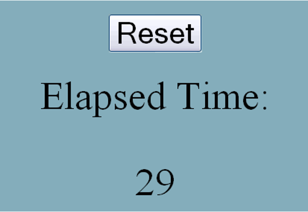

一种 JavaScript 代码版本如下： One version of the JavaScript code would look as follows:

<script type="text/javascript">

var timerID = null;

var elapsedTime = 0;

function doEverySecond() {

elapsedTime += 1;

document.getElementById('curTime').innerHTML = elapsedTime; }

function startTimer() {

timerId = setInterval(doEverySecond, 1000); }

function resetElapsed() {

elapsedTime = 0; }

</script>

<body onload="startTimer()">

<center>Elapsed time</center>

<center>

<div id='curTime'>&nbsp;</div>

</center>

<center>

<input id="reset" type="button" value="Reset" onclick="resetElapsed()" />

</center>

</body>

这里的逻辑分成三部分： There are three parts to the logic here:

1. 每秒更新经过的时间。 Updating the elapsed time every second.
2. 按下按钮时重置计时器。 Resetting the timer on a button-press.
3. 启动计算。 Initiating the computation.

它们通过以下方式完成： These are accomplished as follows:

1. 网页加载时调用 startTimer。 When loaded, the Web page invokes startTimer .
2. 用 elapsedTime 记录已经过了多少时间，并创建一个由 timerID 引用的计时器。这会安装一个每秒（1000 毫秒）触发一次的计时器（并记录其引用，以便以后需要时使用，尽管在这个程序中不需要）。每当计时器触发，就会调用函数 doEverySecond。该函数递增经过的时间，并把当前值写入网页。 We use elapsedTime to record how much time has elapsed, and create a timer, referenced by timerID . This installs a timer (and records a reference to it in case we need it later, which we don’t in this program) that runs every second (1000 milliseconds). Whenever the timer goes off, it invokes the function doEverySecond . That function increments the elapsed time, and writes the current value into the Web page.
3. 最后，重置按钮使用 resetElapsed 作为回调。它重置 elapsedTime 的值，更新后的值会在下次显示更新时呈现。（原则上，我们可能也希望在这个回调里更新显示。） Finally, the reset button has resetElapsed as its callback. This resets the value of elapsedTime , whose updated value is then shown the next time the display is updated. (In principle, we might want to update the display in this callback too.)

假设我们接手维护这个程序。我们想问一个简单问题：网页的 curTime 元素的值是什么？看看我们必须进行怎样的推理： Let us suppose we were given this program to maintain. We want to ask a simple question: what is the value of the Web page’s curTime element? Observe the reasoning we have to perform:

- 它在 doEverySecond 内部被设置。 It is set inside doEverySecond .
- 它被设为 elapsedTime 的值。 It’s set to the value of elapsedTime .
- 这个值在前一条语句中递增。 That value is incremented in the previous statement.
- 每次调用 doEverySecond 时都会发生这次递增。 That increment takes place every time doEverySecond is called.
- 那个调用发生在 setInterval 的第一个实参中。 That call takes place in the first argument of setInterval .
- 那个事件由 startTimer 安装。 That event is installed by startTimer .
- 而 startTimer 在页面加载时被调用。 Which is called on page load.
- 等等。我们还需要知道初始值，也就是 elapsedTime 声明处的值。 Wait. We also need to know the initial value, where elapsedTime is declared.
- 哦，还等等。我们还看到了它被重置。 Oh, but wait. We also see it reset.
- 这发生在 resetElapsed 内部。 That happens inside resetElapsed .
- 而 resetElapsed 在按钮被点击时被调用。 Which is called when the button is clicked.

简言之，我们必须跟踪这一切： In short, we have to follow all this:

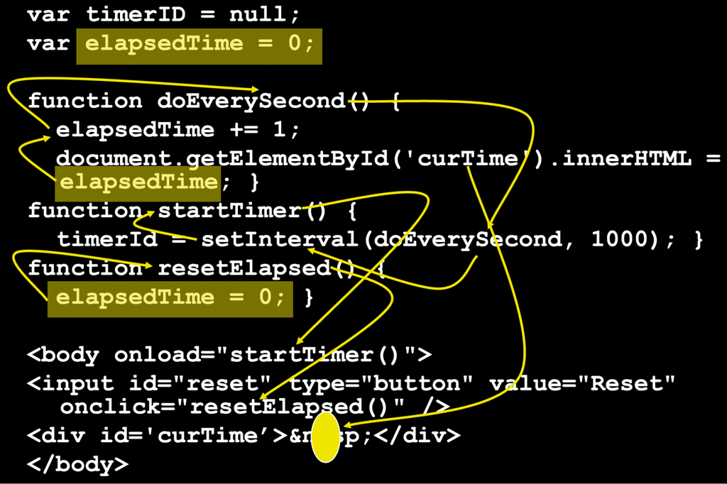

## 响应式 Reactivity

还有一种替代方案，叫作函数式响应式编程（FRP）。我们将看其中一种具体实现，它集成在 Racket 中，并带有一个有趣的用户界面。这种语言叫 FrTime。由于技术原因，我们不用 #lang，而是在 Language 菜单中选择它（位于 Other Languages 下）。 There is an alternative, called functional-reactive programming (FRP). We will see one particular instantiation, which is baked into Racket with an interesting user interface. The language is called FrTime. For technical reasons, we will not use a #lang but rather choose it from the Language menu (under Other Languages).

现在动手！下面这些表达式的输出，最好在 DrRacket 中亲自体验。在 DrRacket 中运行它们，亲眼看看输出！ Do Now! Below are some expressions whose output is best experienced in DrRacket. Run them in DrRacket and see the output for yourself!

FrTime 本质上提供了一个基础版的 Racket，因此基本计算完全如我们所料： FrTime essentially provides a basic version of Racket, so basic computations work exactly as we would expect:

> 5

5

> (+ 2 3)

5

> (string-length "hello")

5

也可以询问当前系统时间这样的值： We can also ask for values like the current system time:

> (current-seconds)

1668363009

> (add1 (current-seconds))

1668363010

你看到的值很可能与上面的不同，因为你阅读这段文字的时间，与我写它的时间不同。但这正是问题所在：实际上，就连我看到的值也是过时的，因为自从我运行命令后，时间已经过去了。 You will likely see a different value than the one shown above, because you are not reading this at the same time as when I wrote it. But that is a problem: indeed, even I am seeing a stale value, because time has passed since I ran the command.

通常的解决办法是使用回调。可以设想有一个接受回调的计时器，每次时间变化时就调用该回调。然而，这会反转控制，正如计时器例子中发生的那样。 The typical solution is to use callbacks. We can imagine a timer that takes a callback, which is called every time the time changes. However, this would invert control, which is exactly what happens in our timer example.

不过，FrTime 遵循 FRP 的原则，提供了一种特殊的值。试一试： But FrTime, following the principles of FRP, provides a special kind of value. Try it:

> seconds

看到发生了什么吗？seconds 是一个随时间变化的值：也就是说，它是（严格说，是求值为）一个值，但求出的值会随时间改变。（实际上，每秒改变一次。） See what happens? seconds is a time-varying value : i.e., it is (technically: evaluates to) a value, but what it evaluates to changes over time. (It changes, in fact, every second.)

自然，我们该问：如果 seconds 求值为一个值，就能在表达式中使用它，那么写出这样的表达式会发生什么？ Naturally, we should ask: if seconds evaluates to a value, we can use it in expressions, so what happens if we write expressions like these?

> (add1 seconds)

> (modulo seconds 10)

注意，add1 和 modulo 都要求第一个实参是数。seconds 是一个随时间变化的值，在每个时刻都是数。因此，这些表达式类型良好，不会产生错误，而且实际上产生了我们可能预期到的答案（但也可能让人有点惊讶）。 Notice that both add1 and modulo demand that their first argument be numbers. seconds is a time-varying value that at every point in time is a number. Therefore, these expressions are well-typed, producing no errors, and in fact produce the answer we might expect (but also perhaps be a bit surprised by).

没有什么能阻止我们编写更长的表达式。考虑函数 build-list： Nothing prevents us from writing even longer expressions. Consider the function build-list :

> (build-list 5 (lambda (n) n))

'(0 1 2 3 4)

如果现在使用一个随时间变化的值，会发生什么？ What happens if we now use a time-varying value?

> (build-list (modulo seconds 10) (lambda (n) n))

或者构建一个嵌套更深的表达式： Or build an even deeper expression:

> (length (build-list (modulo seconds 10) (lambda (n) n)))

## 求值如何工作 How Evaluation Works

### 数据流图 Dataflow Graphs

写下这些表达式时，会发生什么？FrTime 改写了函数应用的发生方式。如果函数的实参都不随时间变化，那么函数求值就和普通 Racket 中一样。不过，只要有任意一个实参随时间变化，FrTime 就会在数据流图中构造一个节点。这个节点连接到那些随时间变化的实参所对应的节点。 What happens when we write these expressions? FrTime rewrites the way function applications happen. If no argument to a function is time-varying, then the function evaluates just as it would in regular Racket. If, however, any of its arguments is time-varying, then FrTime constructs a node in a dataflow graph. This node is attached to the nodes corresponding to the time-varying arguments.

考虑这个表达式： Consider this expression:

(length (build-list (modulo seconds 10) (lambda (n) n)))

调用 length 会对其实际参数求值，而该实参是一次 build-list 调用，后者会对自己的两个实参求值。第二个实参是普通闭包。第一个实参是对 modulo 的调用，它又会对自己的两个实参求值。同样，第二个实参只是一个数，但第一个实参随时间变化。因此，这会变成一个数据流图节点；我们用上下文记法表示随时间变化的值应放在哪里： The act of calling length evaluates its argument, which is a call to build-list, which evaluates its two arguments. The second argument is an ordinary closure. The first argument is a call to modulo, which evaluates its two arguments. Again, the second argument is just a number, but the first argument is time-varying. Consequently, this turns into a dataflow graph node, where we use the context notation to indicate where time-varying values go:

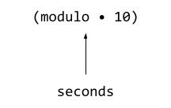

由于 (modulo seconds 10) 求值为一个随时间变化的值，外面一层的表达式也是如此： Because (modulo seconds 10) evaluates to a time-varying value, so does the next outer expression:

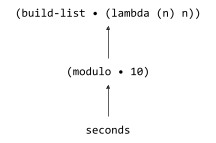

最后，最外层的表达式也是如此： and finally the outermost one:

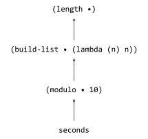

因此，程序源代码求值后得到这个数据流图。现在，每个随时间变化的值可能以不同的频率、因不同的原因而求值。seconds 自然每秒更新一次。更新时，它的新值会推送给所有依赖它的节点，这些节点更新自己的值，再推送自己的值，如此沿着整张图传播。最后，值可能到达 REPL，而 FrTime 的 REPL 被设计为显示这些自动更新的值。 The program source therefore evaluates to this dataflow graph. Now, each time-varying value may evaluate at different rates and for different reasons. seconds , naturally, updates once every second. When it does, its updated value is pushed to all the nodes that depend on it, which update their value and push their values, and so on all the way through the graph. Finally, values may arrive at the REPL, which in FrTime is designed to display them automatically updating.

### 改写应用 Rewriting Application

本质上，我们可以认为响应式是通过改写函数应用的工作方式来实现的。最简单的情况是，假设有一个函数应用 (f a)。再假设 f 本身并不是随时间变化的值。那么，这个应用就把 (f a) 改写为 Essentially, we can think of reactivity being implemented by rewriting how function application works. In the simplest case, imagine we have a function application, (f a) . Let us assume that f is itself not a time-varying value. Then, this application rewrites (f a) as

(let ([a-value a])

(if (time-varying? a-value)

…

(f a-value)))

稍后再回来讨论 …。注意，这会对实参表达式求值，如果它当前不是随时间变化的值，计算就完全按照普通 Racket 的方式继续。这意味着，不使用随时间变化值的程序，其行为与在 Racket 中完全相同，因此这是 Racket 的一个保守扩展。 We will return to the … in a moment. Observe that this evaluates the argument expression and, if it is not currently a time-varying value, then computation proceeds exactly as it would have in regular Racket. This means that progams that don’t use time-varying values behave exactly as they would in Racket, so this is a conservative extension of Racket.

现在考虑参数随时间变化时会发生什么。这意味着我们不能立即计算答案，而必须在数据流图中创建一个节点。可以设想，随时间变化的值是 tvv% 类的对象（tvv 代表 time-varying value，而 % 遵循 Racket 的类命名惯例）。我们先展示它可能如何使用，然后再给出其定义。这个类有两个方法：add-consumer，用来提供另一个 tvv% 对象，让它接收更新值；update，用来接收更新值。我们按下面的方式重现上述数据流图的最下面三个部分，并且为了缩短输出，把对 10 取余改为对 5 取余： Now let’s consider what happens if the parameter is time-varying. That means, instead of immediately computing an answer, we have to create a node in the dataflow graph. We can imagine a time-varying value is an object of the class tvv% ( tvv for time-varying value, and % using the Racket convention for classes). We will first illustrate how this might be used, then show its definition. This class has two methods: add-consumer , which provides another object of tvv% that will receive updated values, and update , which receives updated values. We reproduce the bottom three parts of the above dataflow graph as follows and, to keep the output short, compute the remainder relative to 5 rather than 10 :

(define seconds

(new tvv% [updater (λ (v) v)]))

实际应用中，seconds 会连接到一个每秒推送一次更新的系统计时器。为简单起见，我们让它成为一个不主动变化的对象，只有手动调用它的 updater 时才改变。 In practice, seconds would be attached to a system timer that pushes an update every second. For simplicity, we make it an inert object that only changes when we manually call its updater .

取余节点现在如下： The remainder node now looks like this:

(define mod•5

(new tvv% [updater (λ (v) (modulo v 5))]))

也就是说，每次从 seconds 收到一个值，它就计算该值对 5 的余数。当然，目前它无从知道自己必须监听 seconds；我们得把它注册为消费者： That is, every time it receives a value from seconds , it computes that value modulo 5 . Of course, right now it has no way of knowing that it must listen to seconds ; we have to register it as a consumer:

(send seconds add-consumer mod•5)

类似地，build-list 表达式创建一个随时间变化的值对象： Similarly, the build-list expression creates a time-varying value object:

(define bl•id

(new tvv% [updater (λ (v) (build-list v (λ (n) n)))]))

同样，我们必须把它连接到它的值生产者： which too we must attach to its value producer:

(send mod•5 add-consumer bl•id)

注意，mod•5 和 bl•id 中的 v 参数，如何对应于数据流图中的 •。 Observe how the v parameters in mod•5 and in bl•id correspond to the • in the dataflow graph.

最后，正如 seconds 是图中的源，我们将定义一个打印结果的汇，并把 bl•id 的值发送给它： Finally, just as seconds is a source in the graph, we will define a sink that prints results, and send values from bl•id to it:

(define show

(new tvv% [updater (λ (v) (println v))]))

(send bl•id add-consumer show)

现在，一切都准备好，可以测试了！如果模拟 seconds 在最初十秒内的更新： Now we’re ready to test it all! If we simulate seconds updating for the first ten seconds:

(for-each (λ (n) (send seconds update n)) (range 0 10))

就会看到打印出以下输出，完全符合预期： we see the following output printed, just as we would expect:

'()

'(0)

'(0 1)

'(0 1 2)

'(0 1 2 3)

'()

'(0)

'(0 1)

'(0 1 2)

'(0 1 2 3)

那么，这是如何工作的？tvv% 类维护一个消费者列表，上面的每个对象都只有一个消费者。add-consumer 只是向这个列表中添加成员。update 方法接收一个值，用自己的 updater 函数计算新的当前值，并把它广播给所有消费者： So how did this work? The tvv% class keeps track of a list of consumers, of which above we have had only one per object. add-consumer merely augments this list. The update method receives a value, uses its updater function to compute a new current value, and broadcasts it to all of its consumers:

(define tvv%

(class object%

(init updater)

(define updater-function updater)

(super-new)

(define consumers empty)

(define/public (add-consumer new-consumer)

(set! consumers (cons new-consumer consumers)))

(define/public (update pushed-value)

(let ([new-current-value (updater-function pushed-value)])

(for-each (λ (c) (send c update new-current-value))

consumers)))))

这就是核心逻辑的（大）部分（但请继续读下去）。这让我们回到应用的改写：… 里该放什么？嗯，我们必须 That’s (most of) the core logic (but read on). This brings us back to the rewriting of applications: what goes in … ? Well, we have to

- 创建一个新的 tvv% 实例 make a new tvv% instance
- 给它提供一个对应于 (f •) 的 updater 函数 supply it an updater function that corresponds to (f •)
- 把该节点注册为 a-value 所引用的 tvv% 对象的消费者 registers that node as a consumer to the tvv% object that a-value references
- 返回这个新的 tvv% 实例，作为此次函数“应用”的结果 return the new tvv% instance as the result of this function “application”

练习：把上述改写思路变成一个真正的宏。如果可以，把它变成某个 #lang 的 #%app，以便人们能够用类似 FrTime 的风格编写模块。 Exercise: Turn the above rewriting idea into a proper macro. If you can, turn it into the #%app of a #lang so that one can program a module in a FrTime-like style.

### 非线性图 Non-Linear Graphs

上面的例子可能有点误导人，让人以为表达式总是至多只有一个随时间变化的参数。考虑这个程序： The above example may be a bit misleading in suggesting that an expression must always have at most one time-varying parameter. Consider this program:

(= (modulo seconds 3) (modulo seconds 5))

seconds 每次更新时，依赖它的两个表达式都会更新，其结果流向相等比较。我们预期每 15 秒会看到连续 12 个 false 值，随后是连续三个 true 值，而实际看到的正是如此。 On every update of seconds , both expressions that depend on it update, and their result flows to the equality comparison. Every 15 seconds, we would expect to see 12 consecutive false values followed by three consecutive true values, and that is what we see.

练习：上面的 tvv% 定义允许非线性图吗？能用它写出上述例子吗？如果能，展示如何实现。如果不能，修改它，使它允许这样的定义。 Exercise: Does the above definition of tvv% permit non-linear graphs? Can you write the above example with it? If so, show how. If not, modify it to allow such a definition.

### 避免毛刺 Avoiding Glitches

不过，图中的这些分叉可能值得担心。让我们看一个更简单的例子： These forks in the graph, however, might be a cause for concern. Let us see an even simpler example:

(< seconds (add1 seconds))

首先明确，我们预期它产生什么：我们希望它始终为 #true。 Let us first be clear about what we expect this to produce: we want it to always be #true .

然而，来看看一个简单粗糙的数据流图求值器可能怎样工作。图如下： However, let us view how a simplistic dataflow graph evaluator might work. Here is the graph:

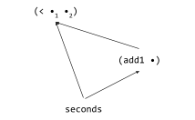

练习：让上面的非线性图定义能够无毛刺地运行。 Exercise: Make the above definition of non-linear graphs behave glitch-free.

## 其他随时间变化的值 Other Time-Varying Values

到目前为止，我们只见过一个基本的随时间变化的值：seconds。FrTime 还提供了许多其他值。例如，mouse-pos 是鼠标的当前位置。如果运行下面的程序： So far we have seen only one basic time-varying value, seconds . FrTime provides many others. For instance, mouse-pos is the current position of the mouse. If we run the following program:

(require frtime/animation)

(display-shapes

(list

(make-circle mouse-pos 10 "blue")))

就会看到一个蓝色圆形，它会自动跟随鼠标。 we see a blue circle, and it automatically follows the mouse.

FrTime 动画库中的 display-shapes 函数接受一个形状列表；上面我们只有一个形状。这个函数构建一个包含（四个）圆形的列表，它们的位置由鼠标位置决定，只不过每一个都有延迟，也就是表示鼠标之前所在的位置。（或许可以把它叫作罗得岛鼠标。）因此，鼠标移动时，这些圆形看起来就像在“跟着”它到处跑。 The function display-shapes in the FrTime animation library takes a list of shapes; above, we have only one. This function builds a list of (four) circles whose positions are determined by the mouse’s location, except each one is delayed , i.e., represents where the mouse used to be. (One might call this the Rhode Island mouse.) Therefore, as the mouse moves these circles appear to “follow” it around.

(display-shapes

(let ([n 4])

(build-list

n

(lambda (i)

(make-circle (delay-by mouse-pos (* 200 (- (- n 1) i)))

10

"green")))))

## 更多随时间变化的值 Even More Time-Varying Values

实际上，我们只见过一种随时间变化的值，叫作行为。随时间变化的值其实有两种，考虑现实世界中的几种不同刺激，就很容易明白： We have actually seen only one kind of time-varying value, called a behavior . There are actually two kinds of time-varying values, which is easy to see if we consider a few different kinds of stimuli from the world:

- 当前鼠标位置 Current mouse position
- 按键序列 Sequence of keystrokes
- 用户当前位置 Current user location
- 网络响应序列 Sequence of network responses
- 模式键的当前状态 Current status of mode keys
- 鼠标点击序列 Sequence of mouse-clicks
- 当前时间 Current time

注意，其中有几项是“当前……”，另外几项是“……序列”。前者的特点是始终有一个值，而且值随时可能改变。后者的特点是，在任意给定时刻都可能没有值——例如，可能不存在“当前按键”——而且我们不知道下一个何时到来（甚至是否会到来），其数量也可能无限。后者当然就是流，通常称为事件流。 Notice that several of those are “current…” and others are “sequence of…”. The former have the property that they always have a value, and the value may change at any time. The latter have the property that at any given moment they may not have a value—for instance, there may not be a “current keystroke”—and we don’t know when (or if) the next one will come, and there may be an infinite number of them. The latter are, of course, just streams , often called event streams .

回到最初的计数器例子，两种值其实都出现了。经过的时间是行为（始终有值，每过完一秒或点击按钮时，这个值就会改变）。相反，按钮按下的序列是事件流：在任意给定时刻可能没有按下事件，我们不知道下一次何时发生，甚至不知道是否还会发生，而且事件数量可能没有上限（来自一个极其无聊的用户）。若想进一步了解，请参阅关于 FrTime 设计与实现的论文，以及关于 JavaScript 中一种类似语言 Flapjax 的论文。 If we go back to our original counter example, we had both present. The elapsed time was a behavior (always has a value, which changes either when a second finishes or when a button is clicked). The sequence of button presses is, conversely, an event stream: at any given moment there may not be a press, we don’t know when or even if the next one will come, and there may be an unbounded number of them (from a very bored user). To learn more, see the papers about the design and implementation of [FrTime](https://cs.brown.edu/~sk/Publications/Papers/Published/ck-frtime/) , and a similar language for JavaScript called [Flapjax](https://cs.brown.edu/~sk/Publications/Papers/Published/mgbcgbk-flapjax/) .

## 回到我们的计时器 Returning to Our Timer

我们可以用 FrTime 的 GUI 库编写最初的计时器程序。下面给出程序并作解释。 We can write the original timer program using FrTime’s GUI library. Here is the program, explained.

### 不带重置的经过时间 Elapsed Time Without Resetting

首先编写一个更简单的版本，只显示程序开始以来经过的时间。为此，需要加载 GUI 库： First we will write a simpler version that simply shows the elapsed time since the program began. To do so, we need to load the GUI library:

(require frtime/gui)

然后，需要确定经过了多少时间。你可能很想写成 and then we need to determine how much time has elapsed. It may be tempting to write

(define init-time seconds)

(define elapsed-time (- seconds init-time))

再创建一个 GUI 显示对象，把它显示出来（先将数转换成字符串）： and then make a GUI display object that presents this (after converting the number into a string):

(make-message (number->string elapsed-time))

然而运行之后，显示结果颇令人失望，似乎始终是 0。那是因为我们要求的正是如此！可以在 REPL 中询问 init-time 的值来验证： When we run this, however, we get a rather disappointing display that seems to always show 0 . That is because that’s what we asked for! We can check this by asking for the value of init-time in the REPL:

> init-time

这样做时，会看到它不断变化。但这本来就在意料之中：我们把它定义为与 seconds 相同！实际上，需要保留的是程序开始时 seconds 的值，也就是说，不希望它自动更新。因此，我们改为写 When we do, we see that it is constantly changing. But that’s what we should expect: we defined it to be the same as seconds ! Instead, we need to hold on to the value of seconds at the time we started the program: i.e., we do not want it to automatically update. For that, we instead write

(define init-time (value-now seconds))

然后程序的其余部分就会如预期那样工作。 and then the rest of the program works as we would expect.

### 添加重置 Adding Resets

现在来添加按钮。创建一个按钮对象，它返回由点击构成的事件流： Now let’s add the button. We create a button object, which returns an event stream of its clicks:

(define reset-clicks (make-button "Reset"))

每次点击时，我们都希望经过的时间重置为 0。也就是说，需要跟踪重置发生的时间。注意，这里同样需要用 value-now 取得事件发生时的时间，而不是当前时间。我们用 map-e 对事件流进行映射： Every time there’s a click, we want the elapsed time to reset to 0 . That is, we want to keep track of when the reset occurred. Note that again we need to use value-now to get the time when it occurred , not the current time. We use map-e to map over event streams:

(define click-times (map-e (lambda (_) (value-now seconds)) reset-clicks))

因此，我们有两种事件：程序开始，以及点击。我们需要一个行为，反映这些事件发生的时间：从程序开始的时刻起步，每次点击时更新。函数 switch 就能做到，在每次事件发生时“切换”行为的值： So we have two kinds of events: the start of the program, and the clicks. We want a single behavior that reflects when these occurred: starting with when the program began, and updating whenever there’s a click. The function switch does this, “switching” the behavior’s value whenever an event occurs:

(define event-times (switch click-times init-time))

此时，需要显示的经过时间，就是当前时间距上一次事件的时长： At this point, the elapsed time to show is how far the current time is from the last event:

(define elapsed-time (- seconds event-times))

图示如下： Visually:

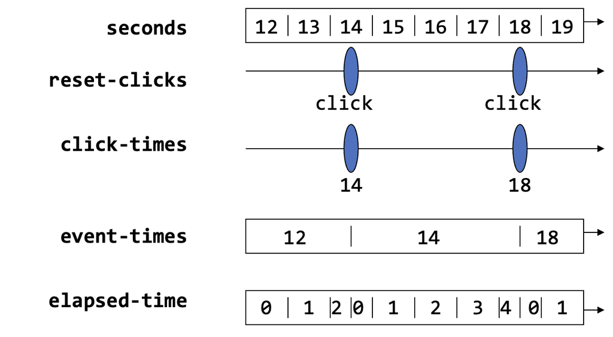

把这一切组合起来，再添加输出指令： Putting this all together, and adding the output directive:

(define init-time (value-now seconds))

(define reset-clicks (make-button "Reset"))

(define click-times (map-e (lambda (_) (value-now seconds)) reset-clicks))

(define event-times (switch click-times init-time))

(define elapsed-time (- seconds event-times))

(make-message (number->string elapsed-time))

注意，在这个程序中，可能发生两种变化： Observe that in this program, there are two kinds of changes that can occur:

- 又过去了一秒。于是 seconds 改变，elapsed-time 也随之改变，因此 make-message 更新输出。 Another second elapses. Thus, seconds changes; so does elapsed-time ; and so make-message updates its output.
- 用户点击按钮。于是 reset-clicks 出现一个事件，因此 click-times 也出现事件，event-times 更新，elapsed-time 也更新，从而使 make-message 同样更新输出。 The user clicks the button. Then reset-clicks has an event, so click-times has an event, event-times updates, and so does elapsed-time , thereby also causing make-message to also update its output.

两种情况下，elapsed-time 都会更新，从而触发输出变化。但 elapsed-time 中的减法有两个输入，而它们因不同的原因更新。 In both cases elapsed-time updates, triggering a change in the output. But there are two inputs to the subtraction in elapsed-time , and they update for different reasons.

上面的讲解为了便于阅读而循序渐进，可能掩盖了这样一个事实：我们实际上拥有深度嵌套的表达式，可以从代数角度思考它们。为了更清楚地说明这一点，下面把整个程序写成一个表达式，将每个名称都替换为它所绑定的表达式（不过，这个版本几乎肯定更难读）： What may be lost in the above presentation, which is incremental to enhance readability, is that we actually have deeply nested expressions that we can think of algebraically. To make that clearer, here is the whole program written as a single expression, with each name replaced with the expression it was bound to (though this is almost certainly a less readable version):

(make-message (number->string

(- seconds

(switch

(map-e (lambda (_) (value-now seconds))

(make-button "Reset"))

(value-now seconds)))))

感兴趣的读者可以纯粹根据代数规则，证明所显示时间的性质，甚至可能发现计时器显示的时间存在一种略令人不满意的行为（回调版本也有这个问题）。 The interested reader can prove properties of the time shown based purely on the rules of algebra, perhaps even identifying a slightly unsatisfying behavior in the time shown by the timer (which was also a problem with the callback version).

这个例子表明，即使我们用 GUI 库编写响应式程序，也确实可以用常规方式组合表达式。不妨把这个程序的结构，与我们最初那个基于回调的版本作一比较。 This example shows that we really can compose expressions in a conventional manner even though we are writing a reactive program using a GUI library. It is worth comparing the structure of this program against the callback-based version that we started with.

这篇论文展示了如何利用面向对象状态的封装，为 GUI 库提供一个函数式响应式接口。 [This paper](https://cs.brown.edu/~sk/Publications/Papers/Published/ick-adapt-oo-fwk-frp/) shows how the GUI library was given a functional-reactive interface by exploiting the encapsulation of object-oriented state.

# ••••• 接下来呢？ ••••• ••••• What’s Next? •••••

你刚刚完成了对编程语言全景的一次细致考察。 You have just finished a detailed look at the landscape of programming languages.

这片天地广阔而丰富，有许许多多值得考虑的维度。 It’s a broad and rich landscape with many, many dimensions to consider.

本书基本上避开了编程语言理论，因为已经有许多关于它的精彩书籍。我推荐： This book has largely eschewed programming language theory , because there are already many wonderful books about that. I recommend:

- Felleisen、Findler、Flatt：《使用 PLT Redex 进行语义工程》（Semantics Engineering with PLT Redex） Felleisen, Findler, Flatt: [Semantics Engineering with PLT Redex](https://mitpress.mit.edu/9780262062756/semantics-engineering-with-plt-redex/)
- Harper：《编程语言实践基础》（Practical Foundations for Programming Languages） Harper: [Practical Foundations for Programming Languages](https://www.cambridge.org/us/academic/subjects/computer-science/programming-languages-and-applied-logic/practical-foundations-programming-languages-2nd-edition?format=HB&isbn=9781107150300)
- Pierce：《类型与编程语言》（Types and Programming Languages） Pierce: [Types and Programming Languages](https://mitpress.mit.edu/9780262162098/types-and-programming-languages/)

它们为进一步学习这个主题提供了三个颇为不同、但都具有奠基作用的视角。 for three rather different, but all foundational, perspectives on the further study of the subject.

同样，编程语言也比以往任何时候都更受欢迎。一线程序员不仅为它们的发展作出贡献，还投入大量精力去理解更高级的特性，并提炼出来讲给他人。他们的成果通常见于博客或各种会议（例如 BOBkonf、!!Con（BangBangCon）、Curry On、Papers We Love、StrangeLoop，以及这里列出的其他会议）——有些仍在活跃举办，有些虽然已经停办，却留下了出色的存档内容。 Equally, programming languages are more popular than ever before. Working programmers not only contribute to their development but also put a great deal of effort into understanding more advanced features and distilling them for others. Their work tends to be found on blogs or at various conferences (such BOBkonf, !!Con (BangBangCon), Curry On, Papers We Love, StrangeLoop, and others [listed here](https://twitter.com/ShriramKMurthi/status/1600574419914854400) )—some are still active, others are not but have great archived content.

我们完成了！希望你阅读本书时，享受到的乐趣和我写作时一样多！ We’re done! I hope you’ve enjoyed reading this as much as I enjoyed writing it!